[figure not shown]

[figure not shown]

聖路加国際病院**ICU**

# 聖路加ICU 年次レポート

2025年度

対象期間 2025年4月1日 〜 2026年3月31日にICUへ入室した患者 データ基準日 2026年09月04日（台帳更新日）｜レポート生成 2026年10月03日

要約を読む 経年推移 全国との比較 図表一覧

はじめに

ICU年次レポート2025年度版が完成しました。対象は、2025年4月1日から2026年3月31日までに ICUへ入室した患者さんです。今回から、**過去6年の推移**と、**全国157施設との比較（JIPAD）**を 新たに加えました。また、医師だけでなく、看護師・薬剤師・理学療法士・管理栄養士・臨床工学技士まで、 ICUに関わるすべての方に読んでいただきたいと思い、図表には簡単な解説を添えています。

あわせて、これまで別のスライドで管理していた**医療の質指標（QI）**を第1章にまとめました。 体制（Structure）・プロセス（Process）・結果（Outcome）の3つに分け、他部署からご提供いただいた 感染・褥瘡・身体拘束などの指標も含めて、**ICUの質を一枚で見渡せる形**にしています。 栄養とリハビリテーションについては、今年度からデータの記録が大きく改善したため、 それぞれ独立した章を設けました。

このレポートは、みなさんが日々ICU台帳にデータを入力してくださっているからこそ、 作ることができました。また、医事課診療事務係の大越さん・田畑さん、医療情報課の堀川さん、 非常勤の谷川先生にも多大なサポートをいただきました。この場を借りて感謝申し上げます。

データを可視化して現場の強みと課題をみんなで共有し、 より安全で質の高いICUづくり——Hotel ICU——につなげる。それがこのレポートの目指すところです。 この結果をもとに、今年度もさらに良いICUにしていきましょう。

聖路加国際病院 集中治療科部長 岡本 洋史

このレポートの読み方

- **各章のはじめに「この章の要点」**があります。忙しいときはここだけ拾ってください。
- 図表のすぐ下の**解説**に、その図から何が言えるかを書いています。
- 下線の引かれた文は、その図表から押さえておきたい要点です。ここだけ拾えば筋は追えます。
- 点線の引かれた用語は、カーソルを乗せる（スマホは長押し）と説明が出ます。
- 横に長い表は、表の中を左右にスクロールできます。

**図表一覧（図 73 点 / 表 44 点）**

図

- 図 1主要指標の推移
- 図 2死亡率とSMRの推移
- 図 3デバイス・治療の推移
- 図 4デバイス・治療の推移
- 図 5疾患群構成の推移
- 図 6疾患群構成の推移
- 図 7診療科構成の推移
- 図 8年齢分布
- 図 9年齢構成の年度推移
- 図 10年齢分類別患者数
- 図 11入室区分 月別推移
- 図 12入室経路
- 図 13入室元病棟
- 図 14患者の流れ（入室経路 → 退室先）
- 図 15酸素デバイス使用 月別推移
- 図 16人工呼吸の期間
- 図 17経腸栄養の開始時間
- 図 18開始できなかった理由
- 図 19開始時間の経年変化
- 図 20月別 早期経腸栄養率
- 図 21月別 目標量への到達
- 図 22曜日別 栄養開始率
- 図 23リハビリの開始時間
- 図 24開始時間の経年変化
- 図 25開始時刻の分布
- 図 26月別 早期離床率の推移
- 図 27曜日別 加算算定率と早期離床率
- 図 28APACHE IIIスコア分布
- 図 29SOFAスコア分布
- 図 30入室前のフレイル（CFS）
- 図 31ICU滞在日数 (全症例)
- 図 32ICU滞在日数 (全症例)
- 図 33ICU滞在日数 (予定術後のみ)
- 図 34ICU滞在日数 (予定術後のみ)
- 図 35ICU滞在日数 (緊急入室のみ)
- 図 36ICU滞在日数 (緊急入室のみ)
- 図 37ICU退室時退室先
- 図 38ICU退室時転帰（全年齢）
- 図 39ICU退室時転帰（年齢別）
- 図 40退院先
- 図 41退院時転帰（全年齢）
- 図 42退院時転帰（年齢別）
- 図 43疾患群ごとのアウトカム
- 図 44疾患群ごとのアウトカム
- 図 45重症度と在室日数の関係
- 図 46再入室までの期間
- 図 47ICU退室後の死亡
- 図 48長期滞在患者の内訳
- 図 49長期滞在の経年推移
- 図 50長期滞在の経年推移
- 図 51診療科別の長期滞在
- 図 52診療科別の長期滞在
- 図 53臓器補助の重なり
- 図 54月別統計
- 図 55日付別統計
- 図 56疾患別(主病名で分類)
- 図 57診療科
- 図 58TOP5診療科の占有率
- 図 59入室（全症例）
- 図 60入室 (予定術後のみ)
- 図 61退室
- 図 62入室時間（全症例）
- 図 63退室時間（死亡除く）
- 図 64挿管時間（全症例）
- 図 65抜管時間（死亡除く 事故抜管含む）
- 図 66曜日×時刻でみる入退室
- 図 67曜日×時刻でみる入退室
- 図 68日別の在室患者数
- 図 69入退室が集中する時間帯
- 図 70長期滞在患者のベッド占有
- 図 71制度開始からの推移
- 図 72病床利用率と算定率
- 図 73算定できなかった管理料（機会損失額）

表

- 表 1医療の質指標 Structure（体制）
- 表 2医療の質指標 Process（プロセス）
- 表 3医療の質指標 Outcome（結果）
- 表 4死亡率とSMRの推移
- 表 5特徴① 内科重症・院内急変のICU
- 表 6実際に多い疾患
- 表 7特徴② 呼吸はHFNC、腎は間欠透析
- 表 8特徴③ 退室先は一般病棟へ直接
- 表 9転帰と標準化死亡比
- 表 10患者基本情報
- 表 11患者基本情報（月別）
- 表 12入室区分・形式・経路・疾患群
- 表 13ICUでの治療 (全期間)
- 表 14経腸栄養の開始時間
- 表 15開始時間の経年変化
- 表 16退室時の目標量到達
- 表 17退室時の目標量到達
- 表 18リハビリテーション関連
- 表 19リハビリの介入率
- 表 20リハビリの介入率
- 表 21リハビリの介入率
- 表 22リハビリの開始時間
- 表 23加算算定と介入記録のずれ
- 表 24開始時間の経年変化
- 表 25曜日別 加算算定率と早期離床率
- 表 26重症度スコア（全症例）
- 表 27重症度スコア（予定術後除く）
- 表 28入室前のフレイル（CFS）
- 表 29転帰の概要（全期間）
- 表 30再入室の深掘り
- 表 31ICU退室後の死亡
- 表 32長期滞在患者の内訳
- 表 33長期滞在の経年推移
- 表 34診療科別の長期滞在
- 表 35診療科別の長期滞在
- 表 36時間外入室と転帰
- 表 37臓器補助の重なり
- 表 38日別の在室患者数
- 表 39特定集中治療室管理料の算定
- 表 40制度開始からの推移
- 表 41登録をやめた場合の損失
- 表 42登録をやめた場合の損失
- 表 43算定できなかった管理料（機会損失額）
- 表 44付録 主要項目の入力率

STORY

2025年度のICUを、数字でたどる

[interactive chart not shown]

1つの点＝患者1人

入室

587人

2025年度にICUへ入室した患者。点1つが1人で、入室した順に並べている。

入口

5つ

手術室から283人（48%）、病棟から141人（24%）、救急外来から87人（15%）。院内のあらゆる場所から患者を受け入れている。

ICU死亡

3.6%

ICUで亡くなったのは21人。前年度は4.7%で、今年度は過去6年で最も低い。

再入室

12.3%

72人が再びICUに戻った。前年度は9.4%で、今年度は過去6年で最も高い。

長期滞在

36%

15日以上ICUにいた47人は入室の8%。その人たちが**延べ在室日数の36%**を使った。

病床

89%

8床に対する利用率（正午時点）。1マスが1日で、濃いほど在室が多い。満床の日（橙）は年間146日あった。

主要指標バッジは前年度との比較

ICU入室患者数

587 例

▲ 34 例前年度 553 例

延べ在室日数

3,157 日

▼ 100 日前年度 3,257 日

ICU在室日数（中央値）

3.0 日

± 0 日前年度 3.0 日

ICU死亡率

3.6 %

▼ 1.1 %前年度 4.7 %

院内死亡率

16.6 %

▲ 2.9 %前年度 13.7 %

SMR（APACHE III）

0.65

▲ 0.07前年度 0.57

人工呼吸実施率

23.3 %

▼ 4.3 %前年度 27.7 %

HFNC利用率

21.6 %

▼ 6.4 %前年度 28.0 %

NPPV利用率

7.3 %

▲ 0.5 %前年度 6.9 %

緊急入室の割合

60.3 %

▼ 4.6 %前年度 64.9 %

再入室率

12.3 %

▲ 2.9 %前年度 9.4 %

15日以上の長期滞在

47 例

▼ 3 例前年度 50 例

早期経腸栄養率（48h以内）

55.6 %

▼ 12.9 %前年度 68.5 %

早期離床率（48h以内）

53.2 %

▲ 0.6 %前年度 52.6 %

緑＝改善 赤＝悪化 灰＝良し悪しを判定しない指標  
SMR（Standardized Mortality Ratio：標準化死亡比）＝ 院内死亡数 ÷ APACHE III による予測死亡数。1より小さいほど「重症度から予測されるより死亡が少ない」ことを表す。

## Summary

**全般**

- ICU入室患者総数は587例で、昨年度の553例から34例増加。一方、15日以上の長期滞在は47例（昨年度50例）と減少した。
- 月別では1月（60例）、12月（57例）、5月（56例）が多く、6月（40例）が最も少なかった。

**患者背景**

- 年齢中央値は71歳（昨年度68歳）と上昇。性別は男性が54.0%（昨年度52.6%）。
- BMIの中央値は21.6（昨年度22.0）で、引き続き痩せ型の患者が多い。
- 入室区分は非手術が51.4%（昨年度56.2%）、手術関連（予定・緊急）が48.6%（昨年度43.8%）。**予定手術が35.8%→39.9%に増え、手術症例の比率が上がった**のが今年度の特徴。
- 入室経路は手術室（48.2%）、病棟（24.0%）、救急外来（14.8%）の順に多い。
- 再入室率は12.3%（72例）で、昨年度の9.4%からさらに上昇した。**過去6年で最も高く、要因の検討が必要。**

**主病名・診療科**

- 主病名は消化器（135例）、神経系（128例）、呼吸器（115例）がほぼ拮抗している。
- 入室診療科は脳神経外科（144例）、消化器・一般外科（101例）、呼吸器内科（64例）、消化器内科（46例）、腎臓内科（35例）の順。

**デバイス管理**

- **人工呼吸器の使用率は23.3%（137例）で、昨年度の27.7%から低下した。** 気管切開も4.3%→3.4%と減っており整合する。
- HFNCは21.6%（昨年度28.0%）と低下、NPPVは7.3%（昨年度6.9%）と横ばい。
- 動脈ラインは95.9%（昨年度94.9%）、中心静脈カテーテルは46.8%（昨年度48.5%）。
- 腎代替療法は間欠的（IHD）48例（8.2%）、持続的（CRRT）7例（1.2%）。VV-ECMOは1例。
- 気管切開は20例（3.4%、昨年度24例）。うち外科的6例、経皮的14例で、**経皮的の比率が昨年度（8例）から大きく増えた**。

**ケア・アウトカム**

- せん妄の発生率は35.4%（208例）で、昨年度の42.5%から低下した。
- 経腸栄養の**48時間以内の開始は55.6%**で、昨年度68.5%から低下し、6年で最も低い（2020年度は77.5%）。退室時に目標量へ届いていたのは蛋白24.7%、エネルギー43.2%。
- リハビリは**早期リハ介入率62.2%**（昨年度61.9%）、早期離床・リハビリテーション加算の算定は88.2%。開始時刻は9〜16時に限られ、夜間・休日に始まる例はない。
- ICU退室時死亡率は3.6%（21例）で、昨年度の4.7%から改善。院内死亡率は16.6%で昨年度13.7%から上昇した。
- 重症度で補正した標準化死亡比（SMR / APACHE III）は0.65（昨年度0.57）。予測死亡率の十分位すべてで実測が予測を下回っており、重症度から期待される水準より死亡は少ない。

**業務フロー**

- 入室元は4E病棟（120例）、ER（98例）、8E病棟（82例）の順に多い。
- 曜日別では火曜日の入室が最多（112例）、日曜日が最少（42例）。退室は火・水・木に集中し、日曜日が少ない。
- 入室時刻は14時前後にピークがあり、深夜帯は少ない。退室時刻は10時にピークがある。
- 抜管は午前10〜11時に集中し、約9割が日勤帯に計画的に行われている。一方ICU入室後の挿管は時刻の偏りが小さく、約半数が夜間帯に発生している。
- 1日あたりの在室患者数（正午時点）は平均7.1人（3〜8人）。8床に対する利用率は89%で、満床の日が年間146日あった。大きな季節変動はなかった。
- 在室日数が長い上位10%の患者が延べ在室日数の41%、上位20%で58%を占めている。

# 1医療の質指標（QI）

- **Donabedianの3分類（体制／プロセス／結果）**で、ICUの質を毎年同じ枠組みで点検する
- 各指標に**過去6年のミニ推移**を添えた。単年の上下ではなく、**線の向き**で読む
- 感染関連・褥瘡・身体拘束・手指衛生・病床利用率は**他部署の集計値**（備考に担当を記載）

早期栄養・早期離床の定義

- **早期栄養率**＝ICU入室後48時間以内に経腸栄養を開始した患者の割合
- **早期離床率**＝ICU入室後48時間以内にリハビリを開始した患者の割合

いずれも**対象はICU滞在が48時間を超え、かつ18歳以上の症例**（今年度237例）。 48時間以内に退室した患者は「48時間以内に開始できたか」を問えないため外し、 栄養の目標設定が成人と異なる小児も除いている。

早期栄養率の分母は、このうち**開始の可否が分かる例**——開始日時が記録された例と、 「48時間以内に開始できなかった理由」が記録された例——に限る。 理由が記録されていれば「開始しなかった」と確定できるため、分母に含めて分子から外す。

早期離床率の分母は、このうち**リハビリ開始日時が記録された例**。 記録が少ないため値の幅は広めに見る必要がある。 別に集計している「早期離床・リハビリテーション加算の算定率」は全例に記録があり、 休日も理学療法士の指示のもとでリハビリを実施して算定しているため、現場の実態にはこちらのほうが近い。 両方を並べて載せているのはこのためで、**2つの値が離れているところは記録の問題を示している**。

Structure体制

人・設備が整っているか。年による変動は小さい

表 1医療の質指標 Structure（体制）

| 指標 | 2024年度 | 2025年度 | 備考 |
| --- | --- | --- | --- |
| 集中治療医の24時間常駐 | あり | あり | 専門医が常時対応 |
| 看護師：患者比 | 2：1 | 2：1 | 夜勤帯も同比率 |
| 薬剤師の常駐 | あり | あり |  |
| 管理栄養士の常駐 | あり | あり |  |
| 理学療法士の常駐 | あり | あり |  |
| インシデントレポートの仕組み | あり | あり | 多職種で共有 |

Processプロセス

正しい手順が踏めているか。改善の打ち手が最も効く層

表 2医療の質指標 Process（プロセス）

| 指標 | 2024年度 | 2025年度 | 2020〜2025年度 | 備考 |
| --- | --- | --- | --- | --- |
| 早期経腸栄養率（48時間以内） | 68.5% | 55.6% |  | ※1 |
| 多職種回診と毎日の目標設定 | あり | あり |  |  |
| 申し送りの標準化 | あり | あり |  |  |
| 鎮痛・鎮静のモニタリング | あり | あり |  |  |
| 多職種カンファレンスの実施 | あり | あり |  |  |
| 患者・家族の満足度評価 | あり | あり |  |  |
| リハビリ介入率（全ICU患者・参考値） | 22.4% | 20.3% |  | ※4 |
| 早期リハ介入率（介入例のうち48時間以内） | 61.9% | 62.2% |  | ※2 |
| 早期離床率（ICU滞在48時間超に限定） | 52.6% | 53.2% |  | ※3 |
| 早期離床加算の算定率 | — | 88.2% | 2025年度から記録 | ※5 |
| 手指衛生遵守率 | 80% | 76% |  | 感染管理室 |
| VAP予防バンドル使用率 | 91% | 96% |  | 感染管理室 |
| 深部静脈血栓予防実施率 | 80% | 73% |  | ICU実施記録 |
| ストレス潰瘍予防実施率 | 75% | 74% |  | ICU実施記録 |
| ICU病床利用率（動態） | 93% | 90% |  | 病床管理 |

**※1** 早期経腸栄養率の分母は、ICU滞在48時間超・18歳以上のうち**開始の可否が分かる例**（開始時刻の記録があるか、「48時間以内に開始できなかった理由」が記録されている例）。  
**※2** **リハビリ部門の定義**による指標。リハビリが介入した症例を分母に、ICU入室から48時間以内に開始した割合を見る。滞在時間や年齢での絞り込みはしない。  
**※3** ※2の分母を「ICU滞在48時間超・18歳以上」に絞ったもの。短期滞在の予定術後（介入例の94%が48時間以内）が抜けるぶん値は下がる。2024年度以前は開始日が日付のみで時刻がないため、その日の正午に開始したと仮定して推定している（※2も同じ）。  
**※4** リハビリ介入率は、除外も条件もつけずICU入室患者全体を分母にした割合。**2024年度7月までは手入力のPT介入欄で算出していたが、その運用が廃止されたため、2025年度はリハビリ開始日時の記録だけで数えた参考値である**（本来の水準は4〜5割）。開始日時は介入があっても残らない場合がある。推移の**破線**は数え方が変わった2024年度以降。「リハビリテーション関連」の章を参照。  
**※5** 正式名称は「早期離床・リハビリテーション加算」。全例に記録があり、休日は理学療法士の指示に基づきリハビリを実施して算定している。48時間以内かどうかは問わないため参考値。  
出典の記載がない指標は、ICU台帳とEx-JIPADから算出している。

Outcome結果

患者にどういう結果が出たか。体制とプロセスの帰結

表 3医療の質指標 Outcome（結果）

| 指標 | 2024年度 | 2025年度 | 2020〜2025年度 | 備考 |
| --- | --- | --- | --- | --- |
| ICU死亡率 | 4.7% | 3.6% |  |  |
| 院内死亡率 | 13.7% | 16.6% |  | 退室後を含む |
| 標準化死亡比（APACHE III） | 0.57 | 0.65 |  | ※5 |
| 再入室率 | 9.4% | 12.3% |  |  |
| せん妄発生率 | 42.5% | 35.4% |  |  |
| ICU在室日数（中央値） | 3.0 日 | 3.0 日 |  |  |
| 長期ICU滞在率（15日超） | 9.0% | 8.0% |  |  |
| 人工呼吸使用率 | 27.7% | 23.3% |  |  |
| 人工呼吸期間（中央値） | 3.4 日 | 3.7 日 |  | MV実施例が分母 |
| 長期人工呼吸率（14日超） | 13.1% | 11.7% |  | 同上 |
| 準夜・夜勤帯の退室率 | 1.7% | 1.2% |  | ※6 |
| 褥瘡発生率 | 0.7% | 0.6% |  | 看護部 |
| 身体拘束実施率 | 40% | 37% |  | 看護部 |
| 人工呼吸関連イベント | 5.6 | 4.7 |  | VAE ※7 |
| 中心静脈カテーテル感染 | 1.56 | 1.69 |  | CLABSI ※8 |
| カテーテル関連尿路感染 | 0.98 | 1.01 |  | CAUTI ※8 |

**※5** 1より小さいほど、重症度から予測されるより死亡が少ないことを表す。  
**※6** 16時以降および0時台の退室。  
**※7** 対1,000人工呼吸器装着日数（感染管理室）。 **※8** 対1,000カテーテル日数（感染管理室）。  
VAE＝人工呼吸器関連イベント、CLABSI＝中心静脈カテーテル関連血流感染症、CAUTI＝カテーテル関連尿路感染症。

# 2年度推移（経年変化）

- 入室587例は前年度から34例増え、6年で2番目（最多は2023年度の600例）。ICU死亡率3.6%は6年で最も低い
- 注目 **再入室率12.3%は過去6年で最高**
- 疾患構成・重症度が6年間安定している

台帳には2020年度以降のデータが入っており、以下は**単年度ではなく年度をまたいだ推移**を示す。 重症度スコア・デバイス・転帰は全年度で欠損がほぼなく、そのまま比較してよい。 一方、Ex-JIPAD由来の項目（栄養・Charlson など）は年度によって入力率が違い、 年度をまたいだ比較には向かない。

## 2.1主要指標の推移

図 1主要指標の推移

[interactive chart not shown]

各パネルのY軸は指標ごとに独立（単位が違うため）。橙の点が今年度。

解説9つの指標を6年分並べた図。橙の点が今年度で、**縦軸は指標ごとに目盛りが違う**ので、 形の上下ではなく点に付いた数値を読んでほしい。

見るべきは3つ。

1. **入室患者数587例は前年度から34例増え、6年で2番目（最多は2023年度の600例）**。一方で延べ在室日数（患者1人1日を1として足し上げたもの）は横ばい、 在室日数の中央値も3日のまま。**患者は増えたのに1人あたりの在室は伸びていない＝ベッドの回転が速くなった**
2. 重症度（APACHE II・SOFAの中央値）は例年並み。**患者が急に軽くなったから回転が速くなったわけではない**
3. **再入室率12.3%は6年で最も高い**。他の指標が安定しているなかで、ここだけが跳ねている

回転が速くなったことと再入室が増えたことは、別々の現象ではないかもしれない。「アウトカムの深掘り」の章で詳しく見る。

## 2.2死亡率とSMRの推移

図 2死亡率とSMRの推移

[interactive chart not shown]

表 4死亡率とSMRの推移

| 年度 | 症例数 | 観測死亡数 | 予測死亡数 | SMR (95%CI) |
| --- | --- | --- | --- | --- |
| 2020年度 | 535 | 69 | 128.3 | 0.54 (0.42–0.68) |
| 2021年度 | 567 | 90 | 150.2 | 0.60 (0.48–0.74) |
| 2022年度 | 485 | 76 | 132.1 | 0.58 (0.45–0.72) |
| 2023年度 | 600 | 111 | 166.0 | 0.67 (0.55–0.81) |
| 2024年度 | 549 | 75 | 130.5 | 0.57 (0.45–0.72) |
| 2025年度 | 584 | 97 | 149.6 | 0.65 (0.53–0.79) |

SMRが1を下回れば「重症度から予測される死亡数より実際の死亡が少ない」ことを意味する。 信頼区間が1をまたぐ年度は、偶然の範囲を超えたとは言えない。

解説**左の図**はICU死亡率（ICUにいる間に亡くなった割合）と院内死亡率（ICUを出た後も含め、その入院中に亡くなった割合）。 今年度は**この2つが逆方向に動いた**。ICU死亡率は下がったのに院内死亡率は上がっている。 これは**ICUを生きて退室した後に亡くなる患者が増えた**ことを意味し、退室の判断や退室先でのフォローを考える手がかりになる。

**右の図のSMR**は少し説明が要る。重症な患者ばかりを診ていれば死亡率は当然高くなるので、 死亡率をそのまま施設間や年度間で比べても意味がない。そこで **「この患者たちなら何人亡くなると予測されるか」を重症度から計算し、実際の死亡数をその予測値で割った**のがSMRである。

- **1.0** ＝ 予測どおり
- **1.0より小さい** ＝ 予測より死亡が少ない（成績が良い）
- **1.0より大きい** ＝ 予測より死亡が多い

帯は95%信頼区間で、**この帯が1.0に届いていなければ「偶然ではなく本当に予測を下回っている」と言える**。 当院は6年間ずっと帯の上端が1.0に届いておらず、**重症度から期待される水準より死亡が少ない状態が続いている**。

## 2.3デバイス・治療の推移

図 3デバイス・治療の推移

[interactive chart not shown]

図 4デバイス・治療の推移

[interactive chart not shown]

解説人工呼吸が23.3%へ、HFNCが21.6%へと、 侵襲的・非侵襲的いずれの呼吸補助も前年度から減った。動脈ラインはほぼ全例、中心静脈ラインは約半数という水準は例年どおりで、 **変化したのは呼吸管理だけ**という読み方ができる。血液浄化・気管切開・ECMOは例年と同程度の低頻度で推移している。

## 2.4疾患群構成の推移

主病名（疾患群）の構成比を、2020年度から順に再生し、2025年度で止まる。 灰色の棒がその年度、点線が2025年度の値。

図 5疾患群構成の推移

[interactive chart not shown]

図 6疾患群構成の推移

[interactive chart not shown]

## 2.5診療科構成の推移

図 7診療科構成の推移

[interactive chart not shown]

解説特定の診療科が突出して増減した年はなく、上位の顔ぶれは安定している。 脳神経外科の予定手術が入室の土台を作り、そこに内科系の緊急入室が乗る、という構造が6年間変わっていない。

# 3全国との比較（JIPAD）

- **当院は「予定術後の回復室」ではなく、内科重症・院内急変を主体とするICU**。緊急入室90.1%（全国71.8%）、非手術77.7%（全国51.5%）
- **他ICUからの転棟が20.4%（全国0.7%）と突出**し、院内全域から重症患者を引き受けている
- **呼吸はHFNC（37.4% vs 16.5%）、腎は間欠透析（11.0% vs 5.7%）**。人工呼吸は少なく、持続透析はほとんど使わない
- **退室先は一般病棟へ直接が81.7%**（全国67.7%）。当院はICUの退室先としてのHCUを持たない運用構造による

そもそもJIPADとは

**JIPAD**（Japanese Intensive care PAtient Database）は、**日本集中治療医学会**が運営する **全国のICU入室患者を集めたデータベース**である。ICU機能評価委員会のJIPADワーキンググループが管理し、 **①医療の質改善・②研究・③医療システムへの貢献**の3つを柱として活動している。

- **何を集めているか** — 患者背景・入室区分・疾患・重症度スコア（APACHE・SOFA）・ICUでの治療内容・ICU退室時と病院退院時の転帰。**退院するまで追いかける**ので、ICUを出た後に亡くなった患者も把握できる
- **どれくらいの規模か** — 2024年度は**157施設・136,162例**。2025年3月末時点の累積は552,304例で、日本のICUを代表するデータベースになっている
- **参加施設に返ってくるもの** — 全国集計の年次レポートに加えて、**自施設と全国を並べた施設別レポート**が届く。この章はそれを読み解いたものである
- **登録は誰がやっているか** — 各施設のスタッフが1症例ずつ手で登録している。当院も毎年、全入室例を登録している

**日々の登録作業がこの比較を可能にしている**。さらにこの登録は、 **特定集中治療室管理料の算定日数延長（14日→25日）の施設基準そのもの**でもある（「特定集中治療室管理料の算定」の章を参照）。

JIPAD事務局から届く施設別レポートには、**全国の参加施設との比較**が載っている。 自前の台帳集計にはない視点であり、**自分たちの数字が「高い・低い」と言えるのは、この比較があってこそ**である。

なお比較は原則、JIPAD分類の**成人重症**（16歳以上・モニタリング症例を除く）で行う。 全症例で見ると術後短期の症例が混ざって当院の特徴が薄まるためで、全国値はいずれも**2024年度**のJIPAD施設別レポート（157施設・136,162例）による。

## 3.1特徴① 内科重症・院内急変のICU

表 5特徴① 内科重症・院内急変のICU

| 項目 | 全国 157施設 | 聖路加 | 差 |
| --- | --- | --- | --- |
| 緊急入室 | 71.8% | 90.1% | ＋18.3pt |
| 非手術 | 51.5% | 77.7% | ＋26.2pt |
| 予定手術 | 28.7% | 11.0% | −17.7pt |
| 緊急コール経由の入室 | 4.9% | 12.6% | 約2.6倍 |
| — 入室経路 — |  |  |  |
| 手術室から | 44.4% | 22.0% | 半分以下 |
| 病棟から | 14.4% | 28.5% | 約2倍 |
| 他のICUから | 0.7% | 20.4% | 約29倍 |
| 救急外来から | 35.5% | 24.5% | −11.0pt |

解説**全国の平均的なICUが術後管理を主体とするのに対し、当院は緊急入室90.1%・非手術77.7%と、内科系・救急系に大きく偏っている。** とりわけ目を引くのが**他のICUからの転棟20.4%（全国0.7%）で、実に約29倍**。CCM/ICCUからの転入が日常的に行われていることを示す。 緊急コール（RRS・コードブルー）経由の入室も全国の2.6倍あり、**院内全域から重症患者を引き受ける構造**が数字に表れている。 手術室からの入室が全国の半分以下であることと合わせ、**「予定術後の回復室」という一般的なICU像は当院に当てはまらない。**

### 実際に多い疾患

表 6実際に多い疾患

|  | 全国 上位10疾患 | % | 聖路加 上位10疾患 | % |
| --- | --- | --- | --- | --- |
| 1 | 手術後 心臓弁手術 | 6.1% | 非手術 その他の代謝性疾患 | 6.7% |
| 2 | 非手術 急性心筋梗塞 | 5.3% | 非手術 誤嚥性肺炎 | 6.5% |
| 3 | 非手術 心停止 | 5.2% | 非手術 細菌性肺炎 | 5.6% |
| 4 | 手術後 消化器腫瘍 | 4.7% | 非手術 敗血症性ショック | 5.1% |
| 5 | 非手術 うっ血性心不全 | 4.2% | 非手術 うっ血性心不全 | 3.8% |
| 6 | 手術後 その他の心血管疾患 | 3.2% | 非手術 消化管出血（上部等） | 3.5% |
| 7 | 手術後 冠動脈バイパス | 3.0% | 非手術 尿路感染による敗血症性ショック | 3.5% |
| 8 | 手術後 大動脈瘤 待機手術 | 3.0% | 非手術 その他の消化器の炎症／感染 | 3.2% |
| 9 | 手術後 消化管穿孔／破裂 | 2.6% | 非手術 リズム異常 | 3.0% |
| 10 | 手術後 急性大動脈解離 | 2.4% | 非手術 てんかん（痙攣） | 3.0% |

病名の読み方（JIPAD疾患分類の約束ごと）

- **「その他の代謝性疾患」**は、低ナトリウム血症・高カリウム血症などの**電解質異常が主体**である
- **「敗血症性ショック」**は**感染源が特定できない**敗血症性ショックを指す。細菌性肺炎による敗血症性ショックのように**原因がわかっている場合は、その原因病名（細菌性肺炎など）の側に計上**される。したがって表の「敗血症性ショック」だけを見ても敗血症の総数にはならない

## 3.2特徴② 呼吸はHFNC、腎は間欠透析

表 7特徴② 呼吸はHFNC、腎は間欠透析

| 治療 | 全国 157施設 | 聖路加 | 差 |
| --- | --- | --- | --- |
| 人工呼吸 | 49.5% | 33.6% | −15.9pt |
| 人工呼吸日数（中央値） | 1.7日 | 4.4日 | 約2.6倍 |
| HFNC | 16.5% | 37.4% | 約2.3倍 |
| NPPV | 9.2% | 9.9% | 同程度 |
| 48時間以内の再挿管 | 2.9% | 4.8% | やや多い |
| — 腎代替療法 — |  |  |  |
| 間欠腎代替療法（IRRT） | 5.7% | 11.0% | 約1.9倍 |
| 持続腎代替療法（CRRT） | 9.0% | 1.1% | 約1/8 |
| — 循環補助 — |  |  |  |
| IABP | 3.6% | 0.0% | 0件 |
| PCPS（VA-ECMO） | 2.3% | 0.5% | 約1/5 |

解説肺炎・呼吸不全が主体でありながら、**人工呼吸は33.6%と全国（49.5%）より16ポイント低い一方、HFNCは37.4%と全国の2.3倍**。 **挿管を避けてHFNCで支える方針**がはっきり数字に出ている。 ただし**いったん挿管すると期間は4.4日と全国（1.7日）の2.6倍**長い。 全国は心臓術後の「翌朝抜管」が多くを占めるためで、当院は長期化する呼吸不全・敗血症が中心という違いによる。

腎代替療法は**持続（CRRT）が1.1%と全国の約1/8である一方、間欠（IRRT）は11.0%と約1.9倍**。 **循環動態が保たれた腎不全に間欠透析で対応している**という運用が読み取れる。 IABPが0件、PCPSも全国の1/5にとどまるのは、心血管症例の少なさと整合する。

## 3.3特徴③ 退室先は一般病棟へ直接

表 8特徴③ 退室先は一般病棟へ直接

| ICU退室先 | 全国 157施設 | 聖路加 | 差 |
| --- | --- | --- | --- |
| 病棟へ直接 | 67.7% | 81.7% | ＋14.0pt |
| HCU経由 | 20.0% | 6.5% | 約1/3 |
| 他のICUへ | 1.3% | 1.1% | 同程度 |
| ICU在室日数（中央値） | 2.8日 | 3.0日 | 同程度 |
| 人工呼吸のまま病棟へ | 11.6% | 12.8% | 同程度 |

解説全国では5人に1人がHCUを経由するのに対し、当院は6.5%にとどまり、81.7%が一般病棟へ直接戻っている。 ただしこの差は診療方針の選択というより、**運用構造による**ところが大きい。 当院は救命救急センター型の施設と違い、**ICUの退室先としてのHCUを基本的に持たない**ため、退室は一般病棟へ直接となる。 在室日数の中央値は3.0日と全国（2.8日）とほぼ同じで、HCUを使わないぶん在室が延びているわけではない。

構造がどうであれ、帰結として**退室後の患者を一般病棟が直接受け止めている**ことに変わりはない。 本レポートで繰り返し出てくる「ICU退室後に亡くなる患者が多い」「再入室率が上昇している」という所見と、 この退室フローは無関係ではない可能性があり、退室後のフォロー体制を考える際の出発点になる。

「HCU」の数字を比較するときの注意

JIPADの退室先分類の「HCU」が、**施設基準（ハイケアユニット入院医療管理料）を満たすHCU**を指すのか、 各施設が慣用的にそう呼ぶ病床を含むのかは、施設側の登録に依存する。 当院のSDUをこの分類でどう扱うかも含め、**施設間で「HCU」の中身が揃っている保証はない**。 全国20.0%との比較は、その前提で幅を持って読むこと。

## 3.4転帰と標準化死亡比

表 9転帰と標準化死亡比

| 転帰・重症度 | 全国 157施設 | 聖路加 |
| --- | --- | --- |
| ICU死亡 | 7.3% | 7.0% |
| 病院死亡 | 14.7% | 18.8% |
| 在院日数（中央値） | 23日 | 27日 |
| APACHE III スコア（中央値） | 54 | 55 |
| APACHE III 予測死亡率（中央値） | 8.0% | 9.4% |
| SMR（APACHE III） | 0.49 | 0.56 |
| SMR（SAPS II） | 0.45 | 0.60 |
| SMR（JROD） | 1.00 | 1.02 |

解説**ICU死亡率は全国とほぼ同じ（7.0% vs 7.3%）だが、病院死亡率は全国より高い（18.8% vs 14.7%）。** 本レポートで繰り返し出てくる「ICUを出た後に亡くなる患者が多い」という所見が、全国比較でも裏づけられる。 在院日数も27日と全国（23日）より長い。

SMRは全国0.49に対し当院0.56とやや高いが、**日本人向けに較正されたJRODで見ると全国1.00・当院1.02とほぼ同じ**になる。 APACHE IIIは日本人の死亡率を過大評価するモデルであり、**SMRの絶対値そのものより年次の変化を追うほうが意味がある。**

# 4患者基本情報

- 年齢中央値71歳、75歳以上が43%
- BMI中央値21.6と全国（22.5）より低く、痩せ型が多い
- 癌転移・免疫抑制が一定数を占め、血液内科・腫瘍内科からの入室を反映

表 10患者基本情報

|  | 全症例 |
| --- | --- |
| 症例数, n | 587 |
| 年齢, years | 71.0 [56.0, 81.0] |
| 男性 | 317 (54.0) |
| 身長, cm | 163.0 [154.4, 169.0] |
| 体重, kg | 57.1 [47.1, 67.5] |
| BMI, kg/m2 | 21.6 [18.9, 24.6] |
| BMI分類 |  |
| 低体重 | 126 (21.5) |
| 普通体重 | 329 (56.0) |
| 過体重 | 102 (17.4) |
| 肥満 | 27 (4.6) |
| 病的肥満 | 3 (0.5) |
| Charlson index | 2.3 (2.2) |
| 再入室 | 72 (12.3) |
| 心停止蘇生後 | 3 (0.5) |
| 免疫抑制 | 81 (14.2) |
| 維持透析 | 38 (6.7) |
| 癌転移 | 39 (6.8) |
| 呼吸不全 | 35 (6.1) |
| 肝硬変 | 18 (3.2) |
| 心不全 | 22 (3.9) |
| AL/MM | 23 (4.0) |
| リンパ腫 | 10 (1.8) |
| 肝不全 | 5 (0.9) |

データは中央値 [四分位範囲]または、number (%)で示した。 BMIカテゴリー - 低体重: BMI < 18.5, 普通体重: 18.5 ≤ BMI < 25, 過体重: 25 ≤ BMI < 30, 肥満: 30 ≤ BMI < 40, 病的肥満: 40 ≤ BMI; BMI (kg/m2), AL/MM: 白血病／多発性骨髄腫, AIDS: acquired immune deficiency syndrome.

解説年齢中央値71歳、BMI中央値21.6。 BMIは全国のICU（JIPAD 2024年度で22.5）よりやや低く、**痩せ型の患者が多い**傾向が続いている。 併存疾患では癌転移・免疫抑制が一定数を占め、腫瘍内科・血液内科からの入室が多い当院の特徴を反映している。

## 4.1患者基本情報（月別）

表 11患者基本情報（月別）

|  | 25年_4月 | 5月 | 6月 | 7月 | 8月 | 9月 | 10月 | 11月 | 12月 | 26年_1月 | 2月 | 3月 |
| --- | --- | --- | --- | --- | --- | --- | --- | --- | --- | --- | --- | --- |
| 症例数, n | 44 | 56 | 40 | 47 | 49 | 47 | 48 | 43 | 57 | 60 | 47 | 49 |
| 年齢, years | 73.0 [53.5, 87.0] | 69.0 [51.5, 79.2] | 72.0 [55.8, 84.2] | 74.0 [63.0, 82.0] | 72.0 [57.0, 81.0] | 70.0 [55.5, 81.5] | 69.5 [56.5, 78.8] | 67.0 [57.5, 78.0] | 68.0 [55.0, 80.0] | 74.5 [59.0, 83.0] | 71.0 [54.5, 78.0] | 75.0 [62.0, 82.0] |
| 男性 | 21 (47.7) | 31 (55.4) | 24 (60.0) | 24 (51.1) | 24 (49.0) | 23 (48.9) | 28 (58.3) | 27 (62.8) | 26 (45.6) | 35 (58.3) | 28 (59.6) | 26 (53.1) |
| 身長, cm | 162.0 [153.8, 168.0] | 163.0 [153.0, 168.5] | 161.5 [152.8, 171.0] | 160.0 [152.5, 167.5] | 162.0 [154.0, 169.0] | 162.0 [154.5, 167.2] | 161.0 [153.8, 170.2] | 164.0 [158.0, 170.3] | 161.0 [155.0, 166.0] | 164.0 [152.8, 168.2] | 164.0 [159.5, 170.2] | 164.0 [158.0, 170.0] |
| 体重, kg | 58.5 [53.3, 66.0] | 57.2 [48.0, 64.9] | 54.8 [44.5, 66.2] | 51.4 [45.8, 62.3] | 57.7 [50.5, 67.8] | 55.4 [44.6, 63.1] | 53.2 [46.5, 64.6] | 60.8 [47.9, 66.8] | 57.5 [49.2, 65.7] | 55.8 [46.6, 68.2] | 58.8 [48.2, 67.8] | 61.3 [53.1, 70.2] |
| BMI, kg/m2 | 22.8 [20.2, 24.9] | 21.3 [18.3, 24.6] | 20.8 [17.9, 24.1] | 20.5 [18.9, 23.4] | 22.7 [19.8, 24.3] | 21.0 [18.3, 24.1] | 20.6 [18.3, 23.3] | 21.7 [19.5, 24.1] | 21.9 [19.0, 25.0] | 21.7 [18.8, 24.3] | 21.8 [18.8, 25.2] | 23.9 [20.6, 26.5] |
| BMI分類 |  |  |  |  |  |  |  |  |  |  |  |  |
| 低体重 | 4 (9.1) | 15 (26.8) | 12 (30.0) | 9 (19.1) | 8 (16.3) | 14 (29.8) | 14 (29.2) | 10 (23.3) | 11 (19.3) | 12 (20.0) | 11 (23.4) | 6 (12.2) |
| 普通体重 | 29 (65.9) | 29 (51.8) | 23 (57.5) | 31 (66.0) | 31 (63.3) | 22 (46.8) | 26 (54.2) | 24 (55.8) | 31 (54.4) | 35 (58.3) | 23 (48.9) | 25 (51.0) |
| 過体重 | 8 (18.2) | 12 (21.4) | 5 (12.5) | 4 (8.5) | 7 (14.3) | 9 (19.1) | 5 (10.4) | 8 (18.6) | 11 (19.3) | 8 (13.3) | 9 (19.1) | 16 (32.7) |
| 肥満 | 2 (4.5) | 0 (0.0) | 0 (0.0) | 3 (6.4) | 2 (4.1) | 1 (2.1) | 3 (6.2) | 1 (2.3) | 4 (7.0) | 5 (8.3) | 4 (8.5) | 2 (4.1) |
| 病的肥満 | 1 (2.3) | 0 (0.0) | 0 (0.0) | 0 (0.0) | 1 (2.0) | 1 (2.1) | 0 (0.0) | 0 (0.0) | 0 (0.0) | 0 (0.0) | 0 (0.0) | 0 (0.0) |
| Charlson index | 1.9 (1.5) | 2.2 (2.0) | 2.3 (2.4) | 2.2 (1.9) | 2.7 (2.6) | 2.4 (2.2) | 2.1 (2.2) | 2.1 (2.8) | 2.0 (2.3) | 2.6 (2.0) | 2.1 (2.1) | 2.6 (2.1) |
| 再入室 | 2 (4.5) | 7 (12.5) | 7 (17.5) | 6 (12.8) | 4 (8.2) | 8 (17.0) | 9 (18.8) | 5 (11.6) | 5 (8.8) | 7 (11.7) | 6 (12.8) | 6 (12.2) |
| 心停止蘇生後 | 0 (0.0) | 0 (0.0) | 1 (2.5) | 0 (0.0) | 1 (2.0) | 0 (0.0) | 1 (2.1) | 0 (0.0) | 0 (0.0) | 0 (0.0) | 0 (0.0) | 0 (0.0) |
| 免疫抑制 | 4 (9.5) | 6 (11.3) | 5 (12.8) | 9 (19.6) | 5 (10.4) | 4 (9.1) | 6 (13.0) | 8 (19.0) | 10 (18.2) | 9 (15.0) | 7 (14.9) | 8 (16.3) |
| 維持透析 | 4 (9.5) | 2 (3.8) | 1 (2.6) | 2 (4.3) | 4 (8.3) | 0 (0.0) | 5 (10.9) | 4 (9.5) | 3 (5.5) | 7 (11.7) | 2 (4.3) | 4 (8.2) |
| 癌転移 | 2 (4.8) | 3 (5.7) | 2 (5.1) | 2 (4.3) | 6 (12.5) | 2 (4.5) | 1 (2.2) | 4 (9.5) | 5 (9.1) | 6 (10.0) | 3 (6.4) | 3 (6.1) |
| 呼吸不全 | 1 (2.4) | 5 (9.4) | 0 (0.0) | 4 (8.7) | 2 (4.2) | 4 (9.1) | 6 (13.0) | 4 (9.5) | 4 (7.3) | 2 (3.3) | 3 (6.4) | 0 (0.0) |
| 肝硬変 | 3 (7.1) | 1 (1.9) | 1 (2.6) | 0 (0.0) | 1 (2.1) | 3 (6.8) | 2 (4.3) | 1 (2.4) | 1 (1.8) | 1 (1.7) | 2 (4.3) | 2 (4.1) |
| 心不全 | 1 (2.4) | 3 (5.7) | 0 (0.0) | 3 (6.5) | 2 (4.2) | 1 (2.3) | 2 (4.3) | 1 (2.4) | 3 (5.5) | 1 (1.7) | 2 (4.3) | 3 (6.1) |
| AL/MM | 1 (2.5) | 5 (9.4) | 1 (2.6) | 3 (6.5) | 1 (2.1) | 0 (0.0) | 3 (6.5) | 2 (4.8) | 2 (3.6) | 3 (5.0) | 2 (4.3) | 0 (0.0) |
| リンパ腫 | 1 (2.4) | 0 (0.0) | 0 (0.0) | 2 (4.3) | 1 (2.1) | 1 (2.3) | 0 (0.0) | 0 (0.0) | 2 (3.6) | 1 (1.7) | 2 (4.3) | 0 (0.0) |
| 肝不全 | 2 (4.8) | 1 (1.9) | 0 (0.0) | 0 (0.0) | 0 (0.0) | 2 (4.5) | 0 (0.0) | 0 (0.0) | 0 (0.0) | 0 (0.0) | 0 (0.0) | 0 (0.0) |

データは中央値 [四分位範囲]または、number (%)で示した。 BMIカテゴリー - 低体重: BMI < 18.5, 普通体重: 18.5 ≤ BMI < 25, 過体重: 25 ≤ BMI < 30, 肥満: 30 ≤ BMI < 40, 病的肥満: 40 ≤ BMI; BMI (kg/m2), AL/MM: 白血病／多発性骨髄腫, AIDS: acquired immune deficiency syndrome.

解説月ごとの患者背景（年齢・BMI・併存疾患）に偏りはなく、特定の月に重症例が集中する傾向は見られない。 **つまり月によって成績に差が出たとすれば、それは患者の違いではなく運用や体制の違いを疑うべき**である。 病床運用で見るべきは「月による患者の質の差」ではなく「月による患者数の差」のほう。

# 5年齢情報

- 75歳以上が43%を占める
- **予定手術（中央値67歳）と緊急入室（74歳）で年齢構成が明確に違う**。混ぜて比較しない
- 年齢が上がるほど緊急入室の比率が高まり、病床の予測可能性は下がる

## 5.1年齢分布

図 8年齢分布

[interactive chart not shown]

## 5.2年齢構成の年度推移

2020年度から順に、年代ごとの割合を再生し、2025年度で止まる。点線は2025年度の値。

図 9年齢構成の年度推移

[interactive chart not shown]

解説年齢中央値71歳。 75歳以上が43%を占める。 **予定手術（中央値67歳・75歳以上34%）と緊急入室（74歳・49%）では年齢構成が明確に違う**。 死亡率や在室日数を比べるときに両者を混ぜると、患者背景の差を診療の差と取り違えることになる。

## 5.3年齢分類別患者数

図 10年齢分類別患者数

[interactive chart not shown]

解説85歳以上は93例。 **年齢が上がるほど緊急入室の比率が高まる**（18-64歳50%、65-74歳62%、75-84歳62%、85歳以上78%）。 高齢の入室ほど予定が立てにくく、**高齢層が増えるほど病床の予測可能性は下がる**。

# 6入室区分と疾患群

## 6.1入室区分・形式・経路・疾患群

表 12入室区分・形式・経路・疾患群

|  |  | 全症例 |
| --- | --- | --- |
| n |  | 587 |
| 入室区分 (%) | 予定手術 | 234 (39.9) |
|  | 緊急手術 | 51 (8.7) |
|  | 非手術 | 302 (51.4) |
| 入室形式 (%) | 予定 | 233 (39.7) |
|  | 緊急 | 354 (60.3) |
| 入室経路 (%) | 手術室 | 283 (48.2) |
|  | 救急外来 | 87 (14.8) |
|  | 病棟 | 141 (24.0) |
|  | CCM/ICCU | 64 (10.9) |
|  | HCU | 11 (1.9) |
|  | 転院直入 | 1 (0.2) |
| 主病名_疾患群名 (%) | 呼吸器 | 115 (20.3) |
|  | 神経系 | 128 (22.6) |
|  | 消化器 | 135 (23.9) |
|  | 代謝性 | 50 (8.8) |
|  | 筋骨皮膚 | 15 (2.7) |
|  | 泌尿生殖器 | 18 (3.2) |
|  | 敗血症 | 32 (5.7) |
|  | 心血管 | 53 (9.4) |
|  | 血液疾患 | 10 (1.8) |
|  | 産婦人科 | 7 (1.2) |
|  | その他内科 | 1 (0.2) |
|  | 外傷 | 2 (0.4) |

解説入室形式では緊急が60.3%を占める。予定手術の患者も一定数いるが、**ICUの運用は緊急入室を軸に組む必要がある**構成である。

## 6.2入室区分 月別推移

図 11入室区分 月別推移

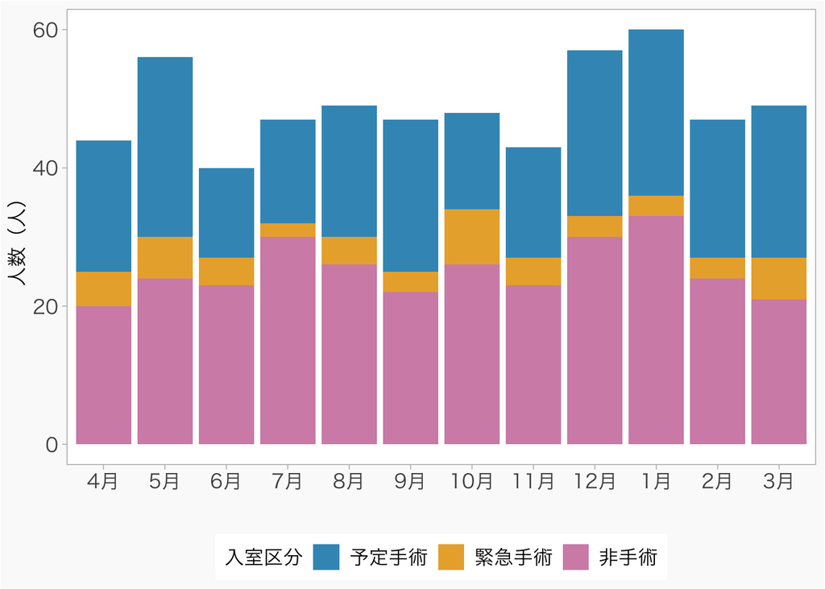

# 7入室経路と入室元病棟

- 手術室からが48.2%で最多。ただし全国（61.6%）より少なく、病棟・救急外来からが相対的に多い
- **入室元はER・4E・8Eが中心**。RRS（院内急変対応）の重点対象を示す

## 7.1入室経路

図 12入室経路

[interactive chart not shown]

解説手術室からが48.2%で最多。 ただしJIPAD全施設の61.6%と比べれば少なく、病棟・救急外来からの入室が相対的に多い。

## 7.2入室元病棟

図 13入室元病棟

[interactive chart not shown]

解説ERと4E・8E病棟が入室元の中心。手術室経由の患者は術前の病棟でカウントしているため、 この図は「どの病棟から重症化した患者が来るか」を示す。**特定の病棟に偏りがあれば、そこがRRS（院内急変対応）の重点対象になる。**

## 7.3患者の流れ（入室経路 → 退室先）

どこから来て、どこへ帰るのか。当院ICUの「院内ハブ」としての働きを1枚の流れ図で示す。 帯の太さが患者数で、帯の上を流れる白い粒は**1粒が患者1人**。帯にカーソルを乗せると実数が出る。

図 14患者の流れ（入室経路 → 退室先）

[interactive chart not shown]

解説左が入室経路、右が退室先。 **手術室・救急外来・病棟・他のICUと、院内のあらゆる場所から患者を受け**、 その大部分を**一般病棟へ直接返している**という当院の構造が、この1枚に集約されている。 どの経路から来た患者も退室先の構成は大きく変わらず、入口によらず同じ出口へ流れる＝ **ICUが院内の共通インフラとして働いている**ことを示す。 経営会議やステップダウン病床の議論には、この図をそのまま使える。

# 8ICUでの治療

- 動脈ラインは95.9%だが人工呼吸は23.3%。**侵襲的呼吸管理は要さないがモニタリングは必要**という患者が主体
- 人工呼吸の実施率は27.7%→23.3%と低下
- 15日以上の長期人工呼吸は人工呼吸例の12%にとどまる

## 8.1ICUでの治療 (全期間)

表 13ICUでの治療 (全期間)

|  | 全症例 |
| --- | --- |
| 症例数, n | 587 |
| 動脈圧ライン | 563 (95.9) |
| 中心静脈ライン | 275 (46.8) |
| 昇圧薬 | 200 (34.1) |
| HFNC | 127 (21.6) |
| NPPV | 43 (7.3) |
| 人工呼吸 | 137 (23.3) |
| 人工呼吸期間 | 3.5 [1.1, 7.0] |
| 8日以上の人工呼吸/人工呼吸 | 31 (23.8) |
| 15日以上の人工呼吸/人工呼吸 | 16 (12.3) |
| 気管切開_総数 | 20 (3.4) |
| 外科的 | 6 (1.0) |
| 経皮的 | 14 (2.4) |
| VV-ECMO | 1 (0.2) |
| 間欠腎代替療法 | 48 (8.2) |
| 持続腎代替療法 | 7 (1.2) |
| 48時間以内の栄養開始 | 237 (52.7) |
| 退室時蛋白>1.0g/kg | 62 (12.5) |
| 退室時エネルギー>20kcal/kg | 99 (19.5) |

データは中央値 [四分位範囲]または、number (%)で示した。 昇圧薬（ノルアドレナリン、ドーパミン、ドブタミン、アドレナリン）＊ピトレシンはデータ収集出来ていない。 (HFNC: high flow nasal cannula, NPPV: noninvasive positive pressure ventilation).

解説動脈ラインは95.9%とほぼ全例に留置されている一方、 人工呼吸は23.3%にとどまる。 **侵襲的な呼吸管理を要さないがモニタリングは必要**という患者が主体であることを示している。 人工呼吸を要した患者のうち15日以上に及んだのは12%で、長期化は一部にとどまる。

## 8.2酸素デバイス使用 月別推移

図 15酸素デバイス使用 月別推移

[interactive chart not shown]

HFNC・NPPVの未入力はなかった。

解説月ごとの治療内容にばらつきはなく、**季節や時期によって呼吸管理の方針が変わっている様子はない**。 NPPVのように件数の少ない治療は、月単位だと数例の違いで大きく動くため、月別の増減に意味を読みすぎないこと。

## 8.3人工呼吸の期間

図 16人工呼吸の期間

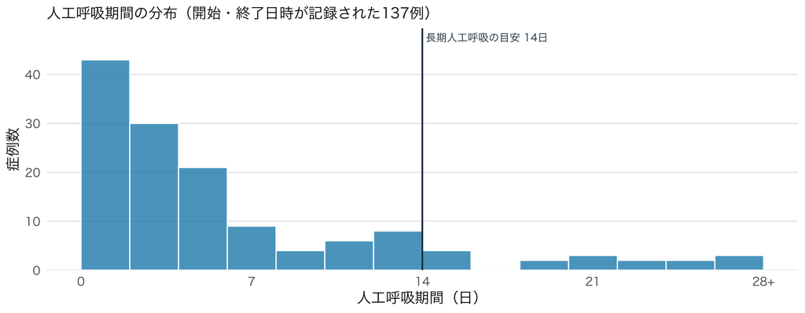

解説人工呼吸を実施した症例の装着期間。中央値3.7日 （四分位範囲 1.4〜7.0日）で、 大半が1週間以内に離脱している。14日を超える長期人工呼吸は16例 （**人工呼吸実施例の11.7%**）。

なお「長期人工呼吸率」は**分母の取り方（全入室か、人工呼吸実施例か）で値が大きく変わる**。 本レポートは人工呼吸実施例を分母とする。他資料と数字を突き合わせるときは、まず分母の定義を確認すること。

# 9栄養関連

- 評価対象は**ICU滞在48時間超かつ18歳以上**（237例）
- 注目 **48時間以内の開始は55.6%**。6年で最も低い。2020年度の77.5%から長期的に下がっている
- 分母は「開始の可否が分かる例」。今年度から**未開始の理由**が記録され、記録漏れと切り分けられるようになった
- 退室時に目標量へ到達しているのは蛋白24.7%・エネルギー43.2%（**ICU滞在7日超・生存退室の81例**が分母）
- 絶食（栄養の記録が一切ない）は1.3%で、国際栄養調査の本邦17.1%と比べて低い

## 9.1経腸栄養の開始時間

「48時間以内に開始できたか」という二値だけでなく、**開始までの実時間の分布**で見る。 比較の物差しは、当院（CCU）も参加した国際栄養調査（INS 2011・人工呼吸患者対象）と、日本版重症患者栄養療法ガイドラインの推奨（48時間以内）である。

この章の分母について

以下の栄養指標は、**ICU滞在が48時間を超え、かつ18歳以上**の症例だけを分母とする（今年度237例）。

- **48時間以内に退室した患者を外す理由** — 栄養を開始する前にICUを出るため、「48時間以内に開始できたか」を問えない。含めると分母が水増しされ、指標が実態より良く見える
- **小児を外す理由** — 栄養の目標量の設定が成人と異なる

図 17経腸栄養の開始時間

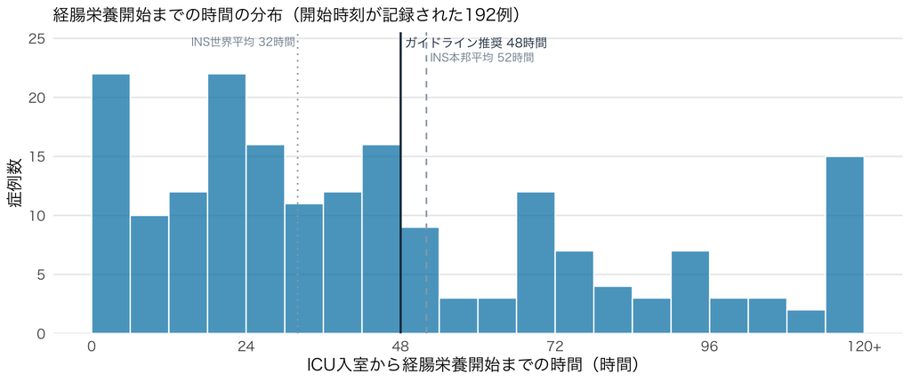

表 14経腸栄養の開始時間

| 指標 | 当院 2025年度 | INS 本邦9施設 | INS 世界175施設 | 目安 |
| --- | --- | --- | --- | --- |
| 経腸栄養開始までの時間 | 中央値 38 時間（四分位範囲 20〜69） | 平均 52 時間 | 平均 32 時間 | ガイドライン 48時間以内 |
| 48時間以内の開始 | 55.6%（開始の可否が分かる216例中） | — | — | 高いほど良い |
| 絶食（48時間以上在室で栄養の記録なし） | 3 / 237 例（1.3%） | 17.1% | 7.7% | 低いほど良い |

解説横軸はICU入室から経腸栄養を開始するまでの時間。 中央値は38時間（四分位範囲 20〜69）、 48時間以内に開始できたのは**55.6%**（開始の可否が分かる216例が分母）だった。

国際栄養調査の本邦平均52時間・世界平均32時間と並べると、**当院は世界平均と本邦平均のあいだに位置する**。 分布を見ると24時間以内に始められている患者が最も多い一方、**48時間の線を越えて右へ伸びる裾も相応にある**のが実態である。

絶食（記録上いっさい経腸栄養が確認できない症例）は237例中3例（1.3%）。 INSでは**本邦の絶食患者17.1%（アジア2.4%）が大きな問題**とされたが、当院にこの問題はほとんどない。

この分布は開始時刻が記録された192例（このコホートの81%）に基づく。 INSの参照値は2011年・人工呼吸患者のみ・平均値のため、厳密な比較ではなく目安である。

### 開始できなかった理由

2025年度から、48時間以内に経腸栄養を開始できなかった症例について**その理由**が記録されるようになった。 「記録がない」のか「意図的に開始しなかった」のかを区別できる。

図 18開始できなかった理由

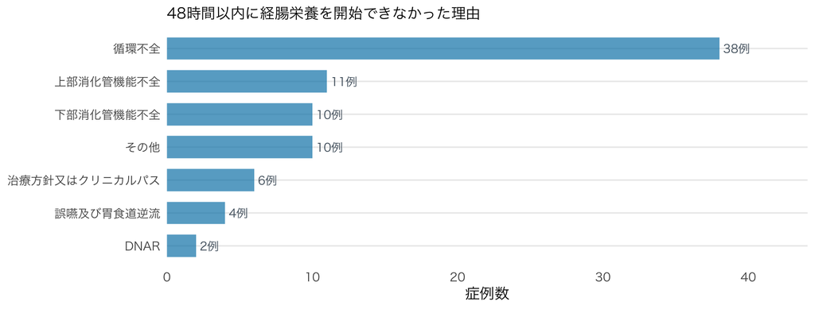

解説最も多いのは**循環不全**で、昇圧薬を要する状態では腸管虚血を避けるため開始を遅らせる、 という日本版ガイドラインの考え方と一致する。次いで上部・下部の消化管機能不全が続き、 **理由の大半は医学的に妥当な判断**である。

一方で「治療方針又はクリニカルパス」やDNARといった、 **患者の状態ではなく方針で決まっている例**も一定数ある。 数としては多くないが、ここは振り返る余地がある。

この理由の記録があることで、**「記録がないから分からない」症例と「意図して開始しなかった」症例を切り分けられる**ようになった。 早期栄養率の分母には、この理由が記録された例も含めている。

### 開始時間の経年変化

図 19開始時間の経年変化

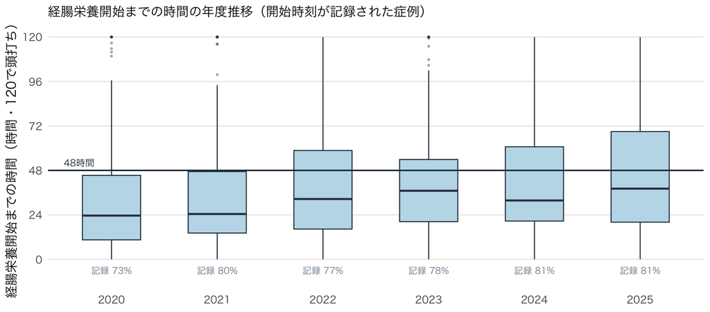

表 15開始時間の経年変化

[output not shown]

この期間を通じて記録率は73〜81%で安定しており、 記録の変化では説明がつかない。**経腸栄養の開始が実際に遅くなっている**と判断してよい。 開始が遅れる要因（循環動態・処置の待機・週末の体制など）の検討が課題になる。

## 9.2月別 早期経腸栄養率

分母：ICU滞在48時間超・18歳以上のうち、開始の可否が分かる症例。図中の n が各月の分母

図 20月別 早期経腸栄養率

[interactive chart not shown]

解説分母はQI章の早期経腸栄養率と同じで、月ごとの症例数は15〜24例。 **1か月の上下動は数例の違いで生じる**ので、傾向を読むなら年単位で見るほうがよい。 月別に見て意味があるのは、特定の月だけ落ち込んでいないかを確認するときである。

## 9.3退室時の目標量到達

「早く始められたか」の次に見るのが「必要な量まで届けられたか」である。 ICU退室時点の投与量を体重あたりで見て、**蛋白1.0g/kg/日以上**・**エネルギー20kcal/kg/日以上**を目標とする。

この指標の分母について

到達率は**ICU滞在が7日を超え、かつ18歳以上で、ICUを生存退室した症例**を分母とする（今年度81例）。 開始の早さ（48時間以内）とは分母が違うので注意してほしい。

⚠ **ここから分母が変わります**。この表は**18歳以上の全症例**をICU滞在日数で層別したもの（563例）

表 16退室時の目標量到達

| ICU滞在日数 | 症例数 | 蛋白 1.0g/kg 到達 | エネルギー 20kcal/kg 到達 |
| --- | --- | --- | --- |
| 2日以下 | 326 | 6.0%（248例中） | 10.2%（256例中） |
| 3日 | 51 | 16.7%（48例中） | 20.4%（49例中） |
| 4〜5日 | 61 | 13.6%（59例中） | 25.4%（59例中） |
| 6〜7日 | 34 | 14.7%（34例中） | 11.8%（34例中） |
| 8〜14日 | 52 | 19.6%（51例中） | 42.3%（52例中） |
| 15日以上 | 39 | 28.2%（39例中） | 38.5%（39例中） |

これは**栄養療法が上手いか下手かではなく、目標量まで上げるのに数日かかるという生理**を映している。 だからこの指標を全症例で見ると、予定術後の短期滞在が多い年ほど成績が悪く見えてしまう。 **評価に使うのは網かけした7日超の帯**で、以降の数字はすべてそこに絞っている。

分母：**ICU滞在7日超・18歳以上**（91例）を、ICU退室時の転帰で分けたもの

表 17退室時の目標量到達

| ICU滞在7日超の症例 | 症例数 | 蛋白 1.0g/kg 到達 | エネルギー 20kcal/kg 到達 |
| --- | --- | --- | --- |
| 生存退室（評価対象） | 81 | 24.7% | 43.2% |
| ICUで死亡（評価から除外） | 10 | 11.1% | 20.0% |

解説7日を超えてICUにいた症例のうち、ICUで亡くなった10例は 蛋白11.1%・エネルギー20.0%と、生存退室例より明らかに低い。

**終末期に投与量を絞るのは臨床判断であって、栄養療法の失敗ではない**。 この10例前後を分母に入れると到達率が数ポイント下がるが、それは診療の質を反映した動きではない。 そのため評価対象は**生存退室例のみ**とし、今年度の到達率は **蛋白24.7%・エネルギー43.2%**（81例）とする。

エネルギーが4割強なのに対し**蛋白は2割台にとどまる**のは、当院に限らず重症患者栄養に共通する傾向である。 経腸栄養剤はエネルギー基準で組まれているため、カロリーを満たしても蛋白が足りない。 **蛋白強化製剤の使用や、蛋白量を独立して処方設計に入れること**が打ち手になる。

## 9.4月別 目標量への到達

⚠ 分母は**この章の他の図とは違います**。**ICU滞在7日超・18歳以上・生存退室**（今年度81例）で、 **月あたり4〜9例**しかありません。図中の n が各月の分母です（3本とも同じ）

図 21月別 目標量への到達

[interactive chart not shown]

解説この図の分母は前節と同じ**ICU滞在7日超・成人・生存退室**で、 月あたり4〜9例しかない（図中の n）。 **1〜2例の違いで割合が大きく動く**ため、たとえば3月の100%は4例中4例、12月の14%は7例中1例という意味である。 見るべきは水準であって月別の凹凸ではない。

7日以上いる患者に絞っても、**開始のタイミング（48時間以内）は達成できているのに到達率が伸びない**という形は年間を通じて変わらない。 長く在室しているのに栄養量が積み上がっていないなら、問題は開始時期ではなく**増量のペース**、 そして**中断（検査・処置・嘔吐・下痢での中止）からの再開の遅れ**にある。

ベッドサイドでは「経腸栄養を開始できたか」で満足せず、**毎日どこまで増やせたか、止めたあと何時間で戻せたかを追う**ことが必要になる。

## 9.5曜日別 栄養開始率

図 22曜日別 栄養開始率

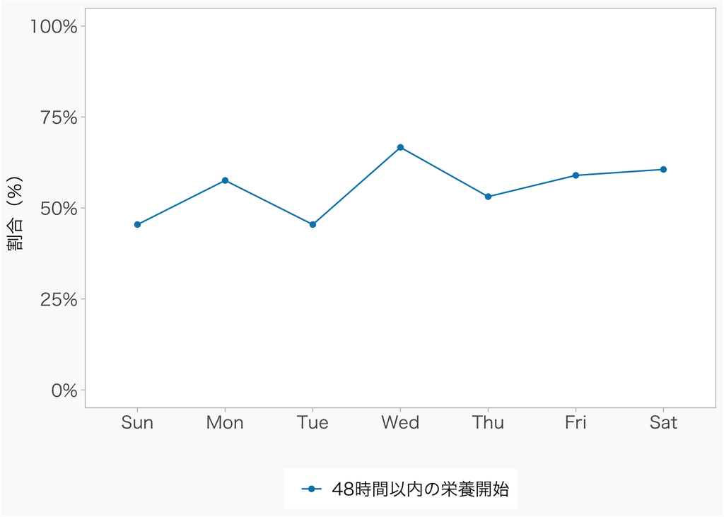

# 10リハビリテーション関連

- 注目 **リハビリ介入率の数え方が2024年度7月に変わった**。PT介入欄が廃止され、2025年度の20.3%は**開始日時の記録だけで数えた参考値**（本来の水準は4〜5割）
- 注目 **早期リハ介入率は62.2%**（介入例のうち48時間以内・リハビリ部門の定義）。ICU滞在48時間超に絞ると53.2%
- 早期離床加算の算定は88.2%
- PTの開始時刻は9〜16時に限られ、夜間・休日に始まる例はない
- ただし**加算の算定率は曜日でほとんど動かない**（金曜93%・日曜96%）。PT記録ベースの「金曜0%」は介入11例がたまたま全部48時間超だったことによる

この章で使う4つの分母

リハビリの指標は**何を分母にするかで数字が大きく変わる**。この章では次の4つを使い分ける。 各図表の直前に、どれを使っているかを必ず書いている。

表 18リハビリテーション関連

| 記号 | 分母 | 今年度の例数 | 何を測るか |
| --- | --- | --- | --- |
| **A** | ICU入室患者の全員（除外なし） | 587例 | ICU全体のどれだけにリハビリが入っているか |
| **B** | Aのうち**開始日時が記録された**症例 | 119例 | **早期リハ介入率**（リハビリ部門の定義）の分母 |
| **C** | ICU滞在48時間超・18歳以上 | 237例 | 「48時間以内」を問える患者の全体 |
| **D** | Cのうち**開始日時が記録された**症例 | 94例 | QI指標「早期離床率」の分母 |

**B・Dは「PTが介入した症例」より狭い。** 開始日時は記録に残る場合と残らない場合があり、48時間以内かどうかを問えるのはここに限られる。

## 10.1リハビリの介入率

早さを見る前に、まず**そもそも誰に介入しているか**を押さえる。

介入率の数え方が2024年度の途中で変わっている

**2024年度7月までは、PT介入欄（手入力）を使ってリハビリの介入率を算出していた。** これが本来の数え方である。その運用が廃止されたため、 **現在は正確なリハビリ介入率を算出できない**。

本レポートでは次のように扱う。

- **2024年度まで**：PT介入欄が「あり」の症例、またはリハビリ開始日時が記録された症例を介入ありとする
- **2025年度**：PT介入欄がないため、**リハビリ開始日時の記録だけで数える**。 この欄は介入があっても残らない場合があるので、**2025年度の介入率は参考値である**

なお2024年度もPT介入欄の記載は7月で止まっており、8月以降は開始日時のみで数えている。 **2024年度の値も実際より低く出ている**。

分母 **A**：その年度のICU入室患者の全員（今年度 587例）。右端の列だけ分母 **B**（リハビリが介入した症例）

表 19リハビリの介入率

| 年度 | ICU入室数 | リハビリ介入 | うちPT介入欄 | うち開始日時の記録 | 早期リハ介入率（48時間以内） |
| --- | --- | --- | --- | --- | --- |
| 2020 | 539 | 200 例（37.1%） | 199 例 | 19 例 | 78.9% |
| 2021 | 567 | 258 例（45.5%） | 219 例 | 100 例 | 67.0% |
| 2022 | 485 | 249 例（51.3%） | 248 例 | 103 例 | 73.8% |
| 2023 | 600 | 268 例（44.7%） | 236 例 | 128 例 | 75.8% |
| 2024 | 553 | 124 例（22.4%） | 56 例 | 97 例 | 61.9% |
| 2025 ＊ | 587 | 119 例（20.3%） | — | 119 例 | 62.2% |

＊ 2025年度はPT介入欄が廃止されており、開始日時の記録だけで数えた参考値。2024年度もPT介入欄の記載は7月で止まっている。

分母 **A**：今年度のICU入室患者を入室区分で分けたもの。右端の列だけ分母 **B**

表 20リハビリの介入率

| 入室区分 | 症例数 | リハビリ介入 | 早期リハ介入率 |
| --- | --- | --- | --- |
| 予定手術 | 234 | 17 例（7.3%） | 94.1% |
| 緊急手術 | 51 | 13 例（25.5%） | 46.2% |
| 非手術 | 302 | 89 例（29.5%） | 58.4% |

解説PT介入欄が使えていた2021〜2023年度は**45〜51%**で、リハビリ部門の実感（5割弱）と一致する。 **これが本来の水準**である。

2024年度22.4%・2025年度20.3%と半分以下に見えるのは、 **PT介入欄が2024年度7月で止まり、開始日時の記録だけになったため**で、診療が減ったわけではない。 2025年度の20.3%は参考値として読んでほしい。

以下は2025年度の内訳だが、同じ理由で**実際より低く出ている**点に注意がいる。 それでも患者構成による差ははっきり出る。 予定手術の患者は7.3%にとどまる一方、非手術は29.5%まで上がる。 診療科別では**脳神経外科・神経血管内治療科の144例は介入0例**で、 その81%が予定手術である。 **術後1〜2日で帰る予定脳外の患者にPTは入らない**——これは長年変わらない当院の構造で、介入率の水準はこの構成で決まる。

対象を絞っていくと数字は次のように動く。

分母：**A** から順に条件を足していったもの。いちばん下が **D** に近い形になる

表 21リハビリの介入率

| 分母の取り方 | リハビリ介入 |
| --- | --- |
| 全ICU患者（除外なし） | 119 / 587 例（20.3%） |
| 脳神経外科・神経血管内治療科を除く | 119 / 443 例（26.9%） |
| ICU滞在48時間超・18歳以上 | 94 / 237 例（39.7%） |
| ICU滞在48時間超・18歳以上、かつ脳外系を除く | 94 / 211 例（44.5%） |

解説もともとPTが入らない診療科を外し、48時間以上ICUにいた成人に絞ると、**5割弱**になる。 2025年度は開始日時の記録だけで数えた参考値だが、この段階まで絞ると **PT介入欄が使えていた年度の水準（45〜51%）に近づく**。 つまり「介入する理由のある患者にはおおむね入っている」という読み方になる。

裏を返せば、**介入率を上げようとしても予定脳外の構成が変わらない限り水準は動かない**。 この指標は改善目標というより、**患者構成が例年どおりかを確認するための指標**として見るのがよい。

## 10.2リハビリの開始時間

栄養と同じく、「48時間以内に開始できたか」の二値だけでなく**開始までの実時間の分布**で見る。 日本版重症患者リハビリテーション診療ガイドラインは、循環・呼吸が安定していれば 早期（おおむね48時間以内）に離床を始めることを推奨している。

リハビリ部門は、**リハビリが介入した症例のうちICU入室48時間以内に開始したものの割合**を **早期リハ介入率**と呼んでいる（分母 **B**）。2025年度は**62.2%**だった。 本レポートではこれに加えて、**ICU滞在48時間超・成人に絞った値**（分母 **D**、53.2%）も併記する。 短期滞在の予定術後は介入例の94%が48時間以内に始まるため、絞ると値は下がる。 どちらが正しいということではなく、 **前者は「介入した患者にどれだけ早く入れたか」、後者は「48時間を問える患者に限った早さ」**を測っている。

分母 **D**：ICU滞在48時間超・18歳以上のうち、リハビリが介入した症例（94例）

図 23リハビリの開始時間

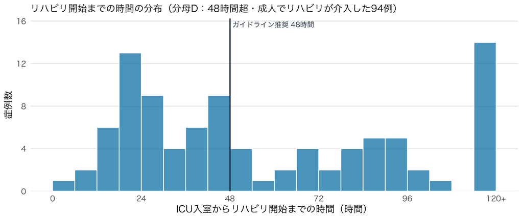

分母：上2行が **D**、加算の算定は **C**（48時間超・成人の全員）、最下行は **C** に対する **D** の割合

表 22リハビリの開始時間

| 指標 | 当院 2025年度 | 目安 |
| --- | --- | --- |
| リハビリ開始までの時間 | 中央値 47 時間（四分位範囲 24〜88） | ガイドライン 48時間以内 |
| 48時間以内の開始 | 53.2%（介入94例中） | 高いほど良い |
| 早期離床・リハビリテーション加算の算定 | 88.2%（209 / 237 例） | 高いほど良い |
| リハビリ介入率 | 94 / 237 例（39.7%） | — |

解説開始までの中央値は47時間（四分位範囲 24〜88）、 48時間以内に開始できたのは**53.2%**だった。

分布は入室翌日（18〜30時間）に山があり、そこから右へなだらかに伸びたあと、 **120時間（5日）を越えてようやく始まる群が14例**という形になっている。 早く始まる群は予定術後や単一臓器障害、遅い群は循環・呼吸が安定するまで待った症例と考えられる。

ただしこの数字は開始時刻が記録された94例（このコホートの40%）に基づく。 残りは**リハビリが介入していない症例**で、介入していない患者を 「48時間以内に開始できなかった」と数えることはできない。 **この値は「PTが入った患者の中での早さ」**である。ICU全体の広がりは次節の加算算定率で見る。

### 加算算定と介入記録のずれ

分母 **C**：ICU滞在48時間超・18歳以上の全員（237例）を、加算の算定有無とリハビリ介入の有無で分けたもの

表 23加算算定と介入記録のずれ

| 早期離床加算 | リハビリ介入あり | 介入なし | 計 |
| --- | --- | --- | --- |
| 算定あり | 88 | 121 | 209 |
| 算定なし | 6 | 22 | 28 |

解説加算は全例に記録があるのに対し、リハビリ開始日時が入っているのは4割弱にとどまる。 **加算と開始日時は対象が違う**ためである。

加算は入室後48時間以内の離床の取り組みに対して算定する。 休日は理学療法士の指示に基づき、医師・看護師でリハビリを実施して算定している。 一方、開始日時はリハビリ職が介入したときに記録される。

この差は入室曜日別に見ると大きく出る（10.5節）。

### 開始時間の経年変化

分母 **D**：各年度の「ICU滞在48時間超・18歳以上のうちリハビリが介入した症例」。図の下の「介入 ○%」は **C** に対する割合

図 24開始時間の経年変化

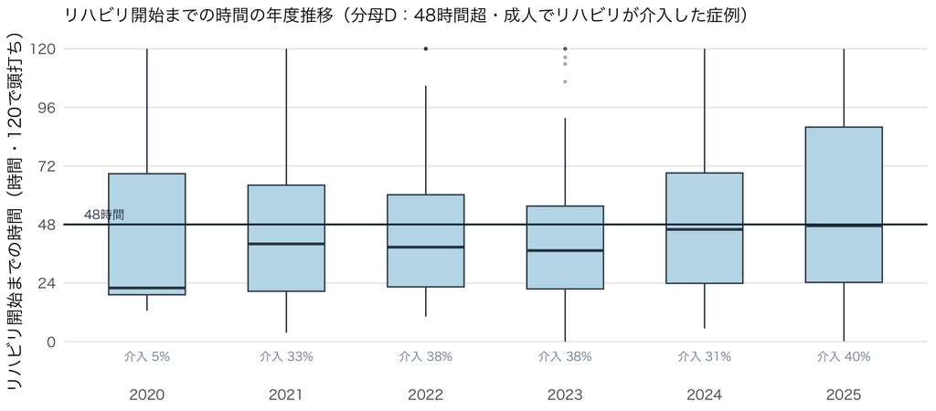

表 24開始時間の経年変化

| 年度 | 入室数 | リハビリ介入 | 開始までの中央値 | 48時間以内 |
| --- | --- | --- | --- | --- |
| 2020 | 238 | 12 例（5%） | 22 時間 ＊ | 66.7% |
| 2021 | 241 | 79 例（33%） | 40 時間 ＊ | 59.5% |
| 2022 | 220 | 84 例（38%） | 39 時間 ＊ | 67.9% |
| 2023 | 266 | 101 例（38%） | 37 時間 ＊ | 69.3% |
| 2024 | 248 | 76 例（31%） | 46 時間 ＊ | 52.6% |
| 2025 | 237 | 94 例（40%） | 47 時間［24–88］ | 53.2% |

＊ 2024年度以前は開始日のみの記録で、その日の正午に開始したと仮定して推定した値。中央値は目安として読むこと。

ひとつ読み方の注意がある。**2024年度以前のこの欄は日付だけで時刻が入っていない**ため、 その日の正午に開始したと仮定して時間を推定している（表の＊印）。 時刻が入るようになった2025年度で答え合わせをすると誤差は数ポイントに収まるが、 **過去年度の値は推定であり、1〜2ポイントの差を追うことはできない**。

2020年度は介入例が12例（5%）しかなく、この項目の登録が始まった年にあたるため比較には使えない。

## 10.3開始時刻の分布

分母 **D** のうち開始時刻まで記録された症例。2024年度以前は日付のみのため、この図は2025年度だけで描いている

図 25開始時刻の分布

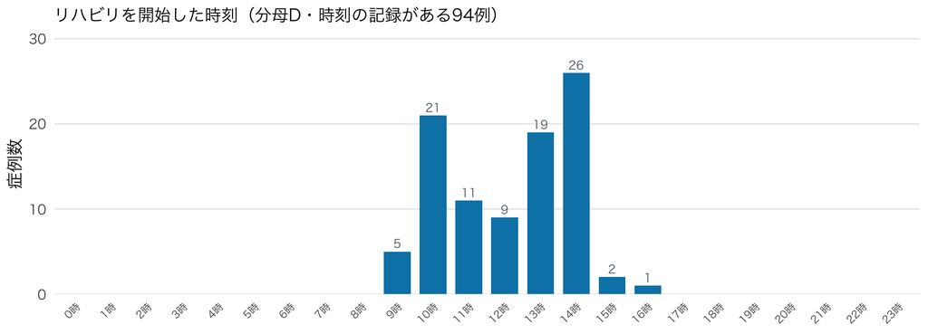

解説開始時刻は**9時から16時にすべて収まっている**。10時台と14時台に山があり、 リハビリスタッフの午前・午後の巡回に対応している。

裏を返すと、**リハビリ職が記録した開始時刻は夜間・早朝・休日にはひとつもない**。 このことは入室曜日別に見ると極端な形で現れる。

## 10.4月別 早期離床率の推移

分母 **D**：入室月ごとに、48時間超・成人でリハビリが介入した症例。図中の n が各月の分母

図 26月別 早期離床率の推移

[interactive chart not shown]

解説月あたりの判定できる症例数は5〜12例と少なく、 **1〜2例の違いで割合が10ポイント以上動く**。月単位の上下に意味を読み込みすぎないほうがよい。

## 10.5曜日別 加算算定率と早期離床率

分母：**加算の算定率は C**（48時間超・成人の全員）、**早期離床率は D**（うちリハビリが介入した症例）。図中の n がそれぞれの分母

図 27曜日別 加算算定率と早期離床率

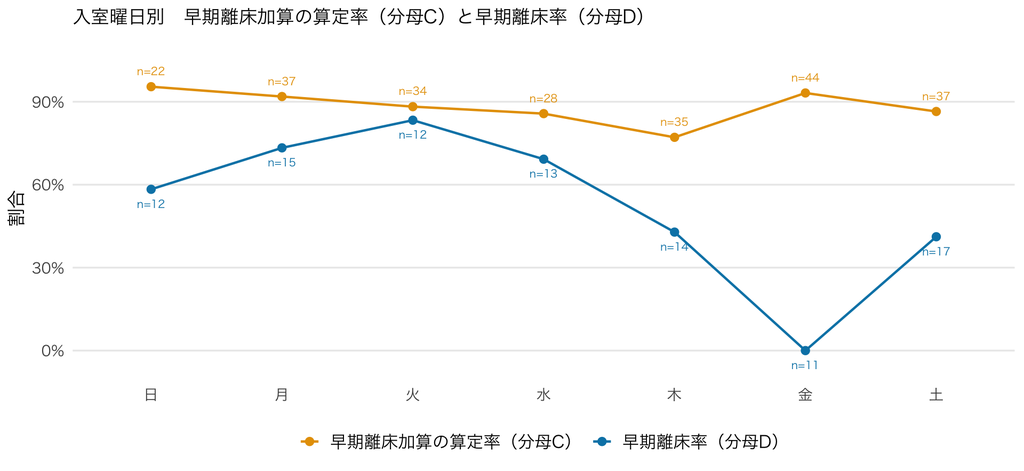

表 25曜日別 加算算定率と早期離床率

| 入室曜日 | 症例数 | 加算の算定率 | リハビリ介入 | 早期離床率 |
| --- | --- | --- | --- | --- |
| 日 | 22 | 95.5%（21例） | 12 例 | 58.3% |
| 月 | 37 | 91.9%（34例） | 15 例 | 73.3% |
| 火 | 34 | 88.2%（30例） | 12 例 | 83.3% |
| 水 | 28 | 85.7%（24例） | 13 例 | 69.2% |
| 木 | 35 | 77.1%（27例） | 14 例 | 42.9% |
| 金 | 44 | 93.2%（41例） | 11 例 | 0.0% |
| 土 | 37 | 86.5%（32例） | 17 例 | 41.2% |

解説2本の線は同じ「早期離床ができたか」を別のソースで見たものである。

**加算の算定率は曜日でほとんど動かない**。金曜93%・日曜96%とむしろ週末寄りが高く、最も低いのは木曜の77%。 休日も理学療法士の指示のもとでリハビリを実施しているため、**週末に入室しても48時間以内の取り組みは行われている**。

一方、早期離床率は金曜だけ0%に落ちる。金曜入室は44例と週で最も多いのに**PTが介入したのは11例**で、 **その11例がたまたま全部48時間を越えていた**——これが正体である。 分母11例で0例なので、統計的にもゼロと断定できる数ではない（95%信頼区間の上限は約28%）。

**曜日別の早期離床率をそのまま体制の問題と読んではいけない**。 分母が11〜17例では、PTが誰に入ったかで数字が振れる。

# 11重症度スコア関連

- APACHE III中央値60点。分布は軽症側に大きく偏る
- **SMRは0.65で1を下回る**。重症度から予測される死亡数より実際の死亡は少ない
- 予定術後を除いても構図は変わらず、患者構成の違いを補正しても成績は保たれている

## 11.1重症度スコア（全症例）

表 26重症度スコア（全症例）

|  | 全症例 |
| --- | --- |
| 症例数, n | 587 |
| ICU退室時_死亡/生存, n(%) | 21/566 (3.6/96.4) |
| 病院退院時_死亡/生存, n(%) | 97/487 (16.6/83.4) |
| APACHE III スコア | 60.0 [41.0, 81.0] |
| APACHE III 院内予測死亡率 (%) | 13.0 [3.9, 40.9] |
| APACHE II スコア | 16.0 [12.0, 22.0] |
| APACHE II 院内予測死亡率 (%) | 18.5 [8.5, 39.9] |
| SAPS II スコア | 32.0 [20.0, 44.0] |
| SAPS II 院内予測死亡率 (%) | 12.8 [3.7, 32.6] |
| SOFA スコア | 4.0 [2.0, 7.0] |
| 標準化死亡比（APACHEIII予測死亡率） | 0.64 |

データは中央値 [四分位範囲]または、number (%)で示した。

解説表の数値は**中央値［四分位範囲］**、または**例数（％）**で示している。四分位範囲は「真ん中の50%の患者が収まる幅」で、平均±標準偏差と違い外れ値に引っ張られない。

APACHE IIIには、患者背景と入室後24時間の生理学的異常から計算される**予測院内死亡率**——「この患者集団なら何％が院内死亡するはず」という値——が付随する。 その予測を全症例分足した数（期待死亡数 E）と、実際に亡くなった数（観測死亡数 O）の比が**SMR = O / E**で、当院は0.65。 1を下回るのは「予測より死亡が少なかった」という意味になる。

ただし**当院は予定手術後の軽症例を多く含む**。軽症例は予測死亡率も実死亡率もともに低いため、比が安定せず、混ぜるほどSMRの解釈は難しくなる。 この数字だけで他施設との優劣は論じられない——**必ず予定術後を除いた下の表と併せて見ること**。

## 11.2重症度スコア（予定術後除く）

表 27重症度スコア（予定術後除く）

|  | 全症例 |
| --- | --- |
| 症例数, n | 353 |
| ICU退室時_死亡/生存, n(%) | 20/333 (5.7/94.3) |
| 病院退院時_死亡/生存, n(%) | 91/260 (25.9/74.1) |
| APACHE III スコア | 76.0 [58.0, 93.0] |
| APACHE III 院内予測死亡率 (%) | 30.9 [13.0, 63.3] |
| APACHE II スコア | 20.0 [16.0, 25.0] |
| APACHE II 院内予測死亡率 (%) | 33.2 [18.9, 53.3] |
| SAPS II スコア | 42.0 [32.0, 51.0] |
| SAPS II 院内予測死亡率 (%) | 28.5 [12.8, 48.4] |
| SOFA スコア | 6.0 [4.0, 9.0] |
| 標準化死亡比（APACHEIII予測死亡率） | 0.68 |

データは中央値 [四分位範囲]または、number (%)で示した。

解説予定術後を除くと重症度・死亡率ともに上がるが、SMRが1を下回る構図は変わらない。 **患者構成の違いを補正しても成績は保たれている**と読める。

## 11.3APACHE IIIスコア分布

図 28APACHE IIIスコア分布

[interactive chart not shown]

解説APACHE IIIは**入室後24時間の生理学的な異常（血圧・呼吸・検査値など）・年齢・持病から重症度を点数化**したもので、 点数が高いほど重症、そこから予測死亡率が計算される。

当院の中央値は60点で、**分布は軽症側に大きく偏り、高得点は少数が裾に長く伸びる**形になっている。 この形のとき**平均値を使うと少数の最重症例に引っ張られて実態より高く出る**ため、 本レポートでは一貫して中央値と四分位範囲で示している。

臨床的には、**ICU患者の大半は「重症度としては中等度」で、ごく一部の最重症例が全体の印象を作っている**ことを意味する。 SMRを見るときも、この少数の重症例の転帰が数字を大きく左右する点は意識しておきたい。

## 11.4SOFAスコア分布

図 29SOFAスコア分布

[interactive chart not shown]

解説SOFAスコアは**6つの臓器（呼吸・循環・肝・凝固・腎・中枢神経）をそれぞれ0〜4点で採点し、合計0〜24点**で表す。 APACHE IIIのように死亡率を予測するためのものではなく、**いまどの臓器がどれだけ傷んでいるかを数える**ためのスコアである。

分布は軽症側に山があるが、APACHE IIIほど極端には偏らず中等症域にも厚みがある。 これは**1臓器あたり最大4点という上限があるため、単一臓器の障害がどれだけ強くてもスコアが伸びきらない**ことによる。 逆にAPACHE IIIは生理学的な逸脱の大きさをそのまま積み上げるので、臓器が1つでも大きく外れていれば高得点になる。 **同じ患者集団でも、2つのスコアは違う姿を映す**——重症度を語るときは、どちらのスコアの話をしているかを明示する必要がある。

ベッドサイドで使うなら、入室時の1点の絶対値より**日々SOFAがどう動くか（増えているか、減っているか）**を追うほうが情報量が多い。

# 12入室前のフレイル（CFS）

- **Clinical Frailty Scale（CFS）はICUに来る前の生活自立度**を1〜9で表す。APACHEやSOFAとは別の情報
- 当院で最も多いのはCFS 3と4で、この2つで6割近く
- 注目 **院内死亡率はCFS 1〜3で2.1%、4〜5で10.3%、6〜9で46.6%**。段階が上がるごとにはっきり差が開く
- 家族への説明と、集中治療の目標を話し合う時期の判断に使える

**Clinical Frailty Scale（CFS）**は、ICU入室**前**にどれくらい自立して生活できていたかを1〜9の9段階で表す指標である。 1が「非常に健常」、9が「終末期」にあたる。 年齢や重症度スコアが「いま目の前の患者がどれだけ重症か」を測るのに対し、 CFSは**どれだけの予備力を持って入室したか**を測る。

図 30入室前のフレイル（CFS）

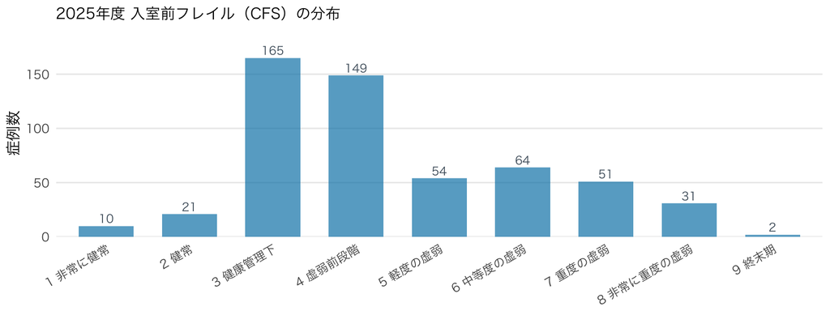

表 28入室前のフレイル（CFS）

[output not shown]

解説当院で最も多いのは**CFS 3（健康管理下）と4（虚弱前段階）**で、この2つで6割近くを占める。

注目すべきは予後との関係である。**CFS 1〜3では院内死亡2.1%、4〜5で10.3%、6〜9では46.6%**と、 段階が上がるごとにはっきり差が開く。重症度スコアが同じでも、**入室前の予備力が違えば結果は変わる**。

実務上の意味は2つある。ひとつは**家族への説明**で、同じ重症度でもCFSが高ければ回復の見通しは変わる。 もうひとつは**入室判断とACP**で、CFS 6以上の患者では集中治療の目標を早い段階で話し合う価値がある。

# 13ICU滞在日数

## 13.1ICU滞在日数 (全症例)

図 31ICU滞在日数 (全症例)

[interactive chart not shown]

図 32ICU滞在日数 (全症例)

[interactive chart not shown]

解説横軸が在室日数、縦軸が患者数。**左端（1〜2日）に高い山があり、右へ長い裾を引く**——右裾分布と呼ばれる形である。 中央値3日（四分位範囲 2-6日）に対し、平均は5.4日と大きく離れる。

この形のときは**平均値で語ってはいけない**。少数の超長期例に引っ張られて、現場の実感よりずっと長い数字が出るためである。 「うちのICUは平均何日」ではなく「中央値3日、4分の3が6日以内」と言うほうが実態に近い。

8日以上は104例、15日以上は47例。 **大多数は数日で退室し、少数が極端に長い**という、どのICUでも見られる典型的な形である。 病床運用の観点では、この右の裾が同時に何本走っているかが日々の空きベッド数を決める（後述「長期滞在患者がベッドをどれだけ使っているか」参照）。

## 13.2ICU滞在日数 (予定術後のみ)

図 33ICU滞在日数 (予定術後のみ)

[interactive chart not shown]

図 34ICU滞在日数 (予定術後のみ)

[interactive chart not shown]

解説予定術後は1〜2日に強く集中する。**術後管理目的の短期入室が明確なパターンとして存在する**ことがわかる。この層はベッドの回転を支える一方、長期化のリスクは低い。

## 13.3ICU滞在日数 (緊急入室のみ)

図 35ICU滞在日数 (緊急入室のみ)

[interactive chart not shown]

図 36ICU滞在日数 (緊急入室のみ)

[interactive chart not shown]

解説緊急入室では分布の裾が長く伸び、長期滞在の大半がこの層から出ている。**病床が詰まる原因は予定手術ではなく緊急入室側にある**ことが、ここでも確認できる。

# 14退室時・退院時の転帰

- ICU退室時の死亡は3.6%、院内死亡は16.6%。**ICUを出た後に亡くなる患者のほうが、ICU内で亡くなる患者より多い**
- 退室先は病棟が90.3%。**ICUの退室可否は一般病棟の受け入れ余力に強く依存する**
- **年齢による差はICU退室時には見えず、退院時にはっきり出る**

## 14.1転帰の概要（全期間）

表 29転帰の概要（全期間）

|  | 全症例 |
| --- | --- |
| 症例数, n | 587 |
| ICU退室時 |  |
| 病棟 | 530 (90.3) |
| CCM/ICCU | 11 (1.9) |
| HCU | 15 (2.6) |
| 転院/退院 | 10 (1.7) |
| 死亡 | 21 (3.6) |
| 準夜/深夜帯の退室, (%) | 3 (0.5) |
| ICU在室日数, days | 3.0 [2.0, 6.0] |
| 8日以上滞在, (%) | 104 (17.7) |
| 15日以上滞在, (%) | 47 (8.0) |
| せん妄 (%) | 208 (35.4) |
| 退院時転帰 |  |
| 生存 | 380 (65.1) |
| 転院 | 107 (18.3) |
| 死亡 | 97 (16.6) |

データは中央値 [四分位範囲]または、number (%)で示した。

解説ICU退室時の死亡は3.6%だが、 院内死亡は16.6%まで上がる。 **ICUを出た後に亡くなる患者のほうが、ICU内で亡くなる患者より多い**という構図であり、 ICU単独の成績だけでは診療の質を評価しきれないことを示している。

## 14.2ICU退室時退室先

図 37ICU退室時退室先

[interactive chart not shown]

解説退室先は病棟が90.3%と大半を占める。**ICUから直接HCUやCCM/ICCUへ移る例は限られており、一般病棟が主な受け皿**である。したがってICUの退室可否は、一般病棟の受け入れ余力に強く依存する。

## 14.3ICU退室時転帰（全年齢）

図 38ICU退室時転帰（全年齢）

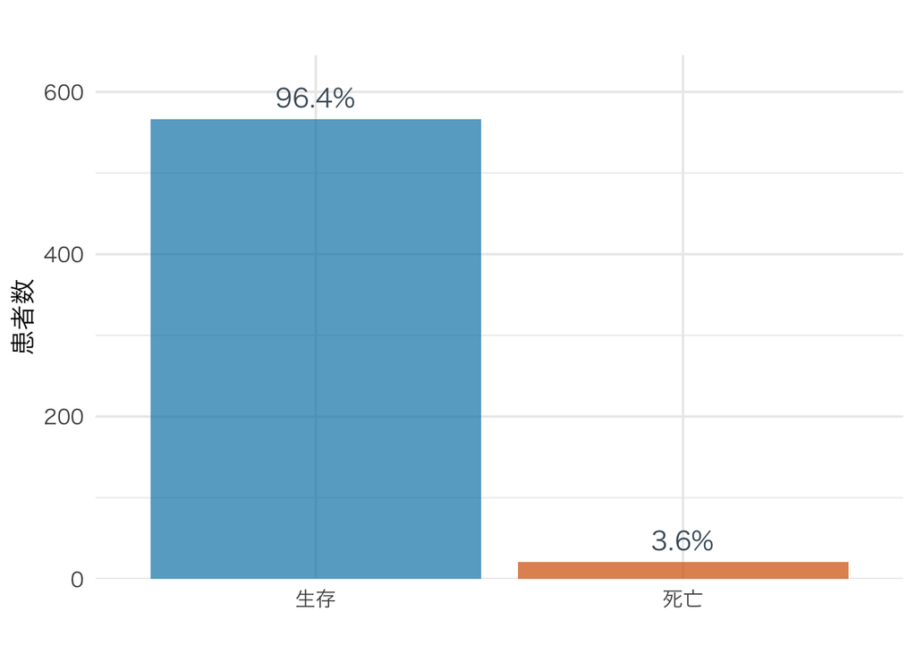

解説ICU退室時点で生存していたのは96.4%で、ICU内で亡くなる患者は限られている。 ただしこれは**「ICUを出た時点」だけを切り取った成績**である。次の「退院時転帰」と比べると、退室後に亡くなる患者が相当数いることがわかる。 **ICU死亡率は単独で読まないこと。**

## 14.4ICU退室時転帰（年齢別）

図 39ICU退室時転帰（年齢別）

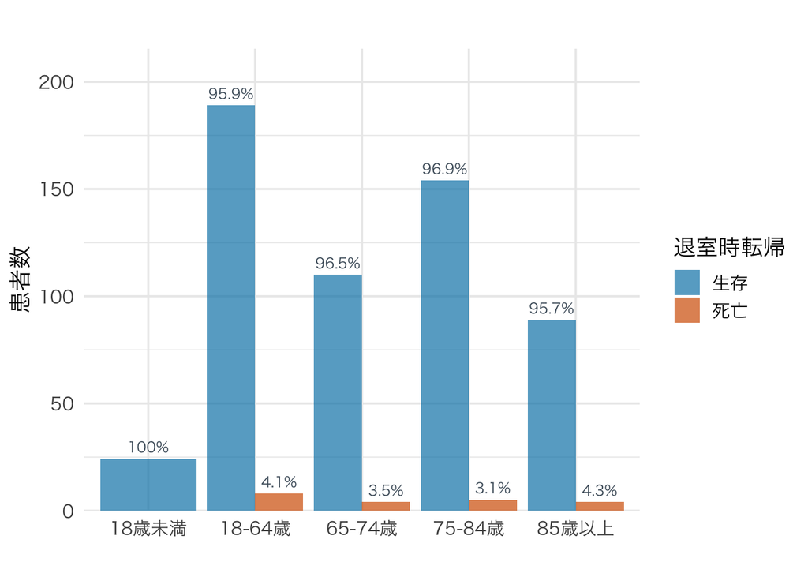

## 14.5退院先

図 40退院先

[interactive chart not shown]

## 14.6退院時転帰（全年齢）

図 41退院時転帰（全年齢）

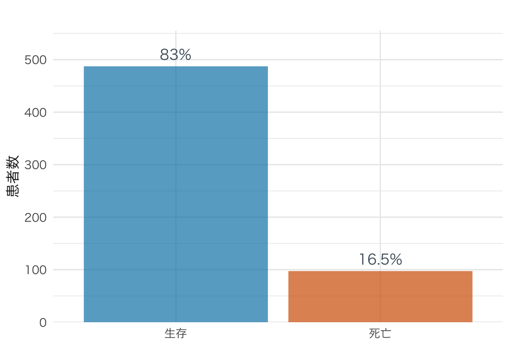

解説ICU退室時の死亡は3.6%だったが、退院時点では16.6%になる。 **この差はすべて、ICUを生きて退室したあとに病棟で亡くなった患者である**。

ICU死亡率は「ICUという場所での治療がどうだったか」を測る指標だが、**患者にとっての結果は退院時点の転帰**であり、この2つは別物として扱う必要がある。 ICUの成績だけを見ていると、退室判断が早すぎた例、ICUでは持ち直したが病勢そのものは止められなかった例、ICUを出てから看取りの方針に切り替わった例が、まとめて視野から外れる。

この差の中身（どんな患者が、退室後どれくらいで亡くなっているか）は、後の**「ICUを生きて退室した後に亡くなった患者」**で詳しく見る。

## 14.7退院時転帰（年齢別）

図 42退院時転帰（年齢別）

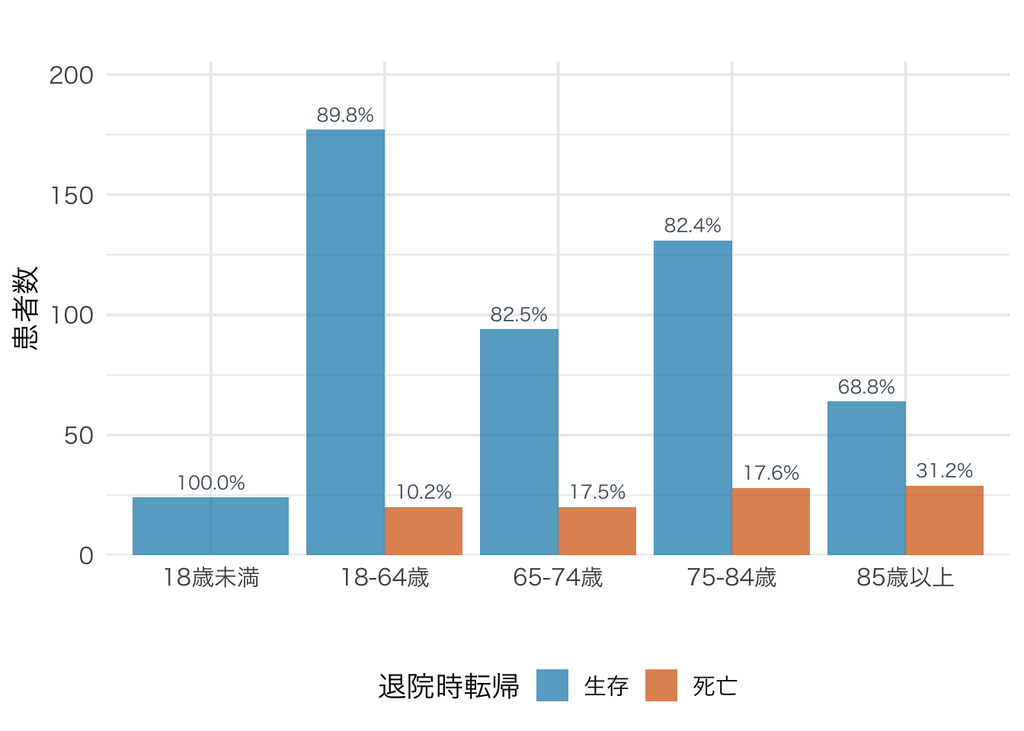

解説退院時点では年齢による差がはっきりする。ICU退室時には見えなかった差が 退院までの経過で現れており、**高齢患者の予後はICUを出た後の経過に強く左右される**ことを示している。

# 15アウトカムの深掘り

- 疾患群は中央値の差より**ばらつきの差**が大きい。病床の見通しを立てにくいのはばらつきの大きい群
- 再入室例の院内死亡は2.8倍だが、相当部分は重症度で説明できる。**見るべきは48時間以内の再入室9例**
- **院内死亡97例のうち76例（78%）はICUを生きて退室した後に亡くなっている**
- 15日以上の長期滞在47例が延べ在室日数の36%を使っている

## 15.1疾患群ごとのアウトカム

図 43疾患群ごとのアウトカム

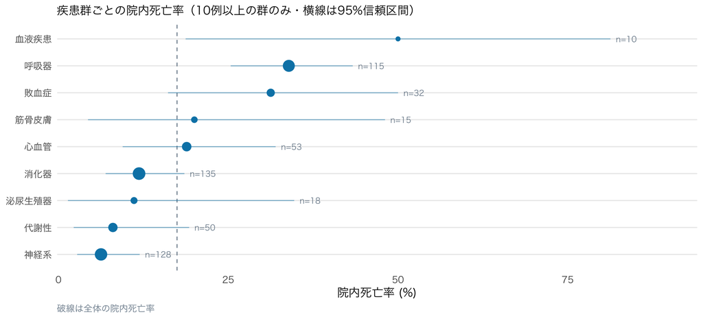

図 44疾患群ごとのアウトカム

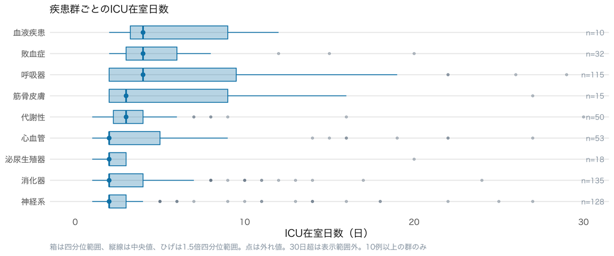

解説箱ひげ図の読み方から。**箱**は真ん中の50%の患者が収まる範囲（四分位範囲）、 **箱の中の縦線**が中央値、**箱から伸びるひげ**がおおよその分布の広がり、**点**が外れ値である。 **箱が横に長いほど、同じ疾患群でも患者ごとに在室日数がばらついている**ことを意味する。

**病床運用で扱いにくいのは、中央値が長い群ではなくばらつきが大きい群**である。 中央値が長くてもばらつきが小さければ計画は立つが、 ばらつきが大きい群は「何日空くか読めない」ため、ベッドの調整を難しくする。

## 15.2重症度と在室日数の関係

図 45重症度と在室日数の関係

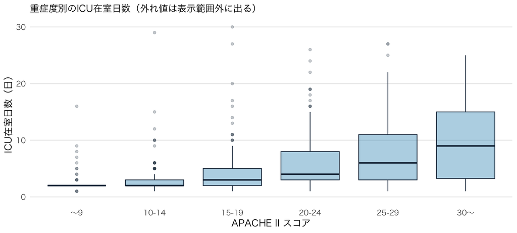

解説横軸をAPACHE IIスコアの帯で区切り、帯ごとの在室日数を箱ひげ図で見たもの。 **重症度が上がるほど在室日数は単調に延びる**（9点以下で中央値2日 → 30点以上で9日）。途中で頭打ちになったり逆転したりはしない。

注目してほしいのは中央値だけでなく**箱の縦の広がり**で、重症帯ほど箱が縦に伸びる。 これは同じ重症度の中に「3日で出る人」と「3週間かかる人」が混在するという意味で、**重症例は長引くだけでなく、どれだけ長引くかの読みが難しい**ことを表している。

実務上の使い方としては、入室時のAPACHE IIから**集団としての平均的な在室日数は見積もれるが、目の前の患者の退室日を当てることはできない**と理解しておくとよい。 病床計画には使えるが、個々の患者・家族への説明に「このスコアなら何日です」と持ち出すのは適切ではない。

## 15.3再入室の深掘り

再入室率は今年度12.3%と過去6年で最も高い。 率だけでは対策が立たないため、**誰が・いつ・どうなったか**を分解する。

表 30再入室の深掘り

| 項目 | 再入室あり | 再入室なし |
| --- | --- | --- |
| 症例数 | 72 例 | 515 例 |
| 年齢（中央値） | 74 歳 | 70 歳 |
| APACHE III（中央値） | 80 点 | 56 点 |
| ICU在室日数（中央値） | 4 日 | 3 日 |
| 人工呼吸 | 34.7% | 21.7% |
| ICU死亡 | 6.9% | 3.1% |
| 院内死亡 | 38.6% | 13.6% |

解説**再入室例の院内死亡率は38.6%で、再入室しなかった患者（13.6%）の約2.8倍。** ただし**この差の相当部分は重症度で説明できる。** 再入室例のAPACHE IIIは80点と、 再入室しなかった患者の56点より明らかに高い。 ここで示しているのは**再入室時点**の重症度なので、状態が悪化して戻ってきた患者が重症であるのは当然ともいえる。

つまり「再入室率が上がった＝退室の判断が悪化した」と短絡してはいけない。 退室判断の妥当性を問うのであれば、次の**48時間以内の再入室**を見るほうが的確である。

### 再入室までの期間

図 46再入室までの期間

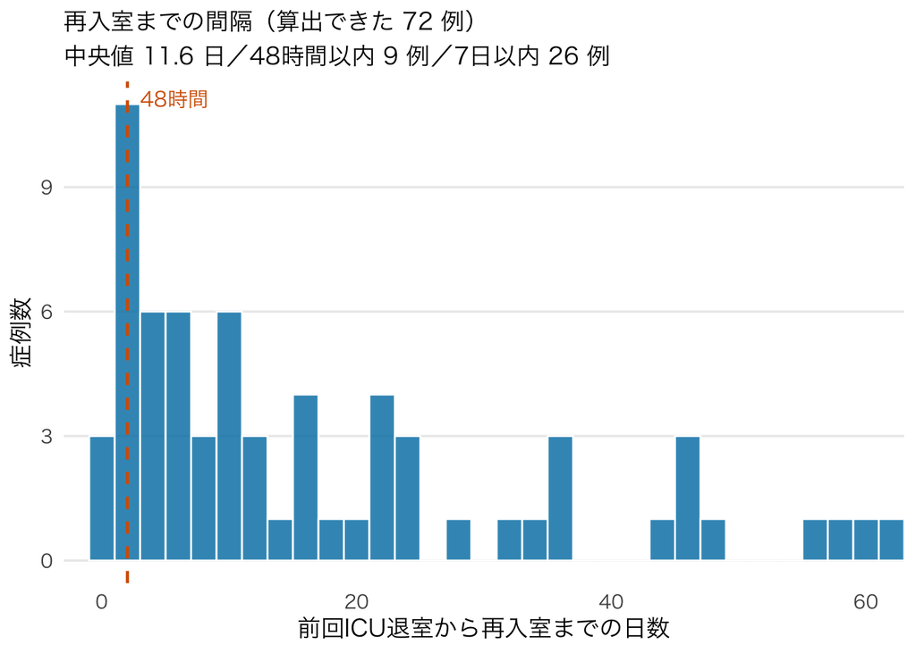

解説**48時間以内の再入室が9例、7日以内が26例。** 48時間以内の再入室は国際的にも「早すぎる退室」の代表的な指標とされる。 一方、中央値は11.6日と幅があり、**大半は退室判断とは別の要因（原疾患の再燃・新たな合併症）による再入室**と考えられる。 対策を打つなら、まず48時間以内の9例を個別に振り返るのが費用対効果が高い。

## 15.4ICU退室後の死亡

ICU死亡率と院内死亡率が逆方向に動いた理由をここで分解する。

図 47ICU退室後の死亡

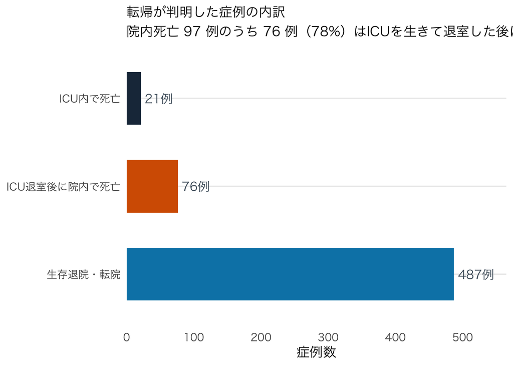

表 31ICU退室後の死亡

| 項目 | ICU退室後に死亡 | 今年度全体 |
| --- | --- | --- |
| 症例数 | 76 例 | 587 例 |
| 年齢（中央値） | 78 歳 | 71 歳 |
| APACHE III（中央値） | 88 点 | 60 点 |
| ICU在室日数（中央値） | 4 日 | 3 日 |
| 人工呼吸 | 26% | 23% |
| 緊急入室 | 93% | 60% |

解説**院内死亡97例のうち76例（78%）は、ICUを生きて退室した後に亡くなっている。** つまり**ICUで亡くなる患者より、ICUを出てから亡くなる患者のほうがはるかに多い**。

この群の特徴を全体と比べると、輪郭がはっきりする。

**ICU死亡率3.6%という良好な数字の裏側で何が起きているかを知るには、この群の個別レビューが要る。** 終末期の方針決定がICUの外で行われている可能性も含め、確認する価値のある領域である。

## 15.5長期滞在患者の内訳

病床運用の章で示すように、在室日数の長い上位10%が延べ在室日数の4割を占める。ここではその患者像を明らかにする。

表 32長期滞在患者の内訳

| 項目 | 15日以上滞在 | 今年度全体 |
| --- | --- | --- |
| 症例数 | 47 例 | 587 例 |
| 延べ在室日数に占める割合 | 36% | 100% |
| 年齢（中央値） | 68 歳 | 71 歳 |
| APACHE III（中央値） | 90 点 | 60 点 |
| 人工呼吸 | 85% | 23% |
| 腎代替療法 | 38% | 8% |
| 気管切開 | 36% | 3% |
| ICU死亡 | 11% | 4% |
| 院内死亡 | 30% | 17% |

図 48長期滞在患者の内訳

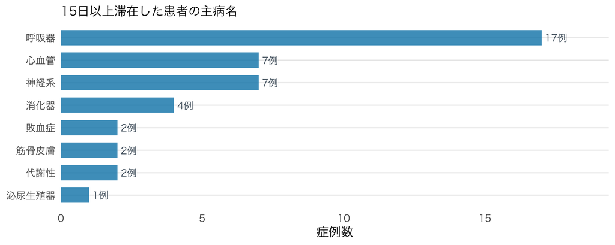

解説**わずか47例（全体の8.0%）が、延べ在室日数の36%を使っている。** この群は人工呼吸85%・腎代替療法38%・気管切開36%と、**臓器補助を要する重症例に明確に偏っている**。 主病名では呼吸器が最も多い。

**病床の余裕をつくる打ち手は、この層に集中させるのが合理的。** 短期入室を数人減らすより、長期滞在を1人減らすほうが効果が大きい。 人工呼吸器離脱・気管切開のタイミング・転院調整といった、この層に固有のプロセスが検討対象になる。

### 長期滞在の経年推移

図 49長期滞在の経年推移

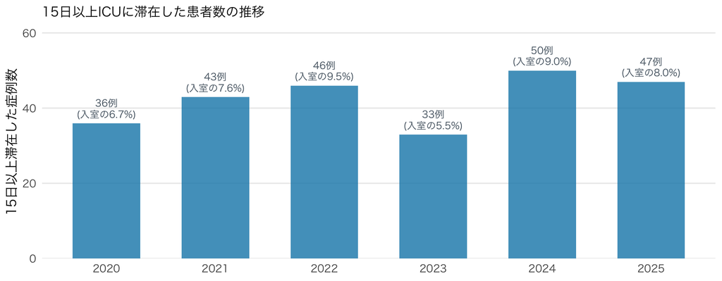

表 33長期滞在の経年推移

| 年度 | 入室数 | 15日以上 | うち30日以上 | 最長在室 | 延べ在室日数 | うち長期滞在分 |
| --- | --- | --- | --- | --- | --- | --- |
| 2020 | 539 | 36 | 10 | 67 日 | 2,845 | 909 日（32%） |
| 2021 | 567 | 43 | 10 | 74 日 | 3,082 | 1,127 日（37%） |
| 2022 | 485 | 46 | 11 | 158 日 | 3,144 | 1,388 日（44%） |
| 2023 | 600 | 33 | 9 | 122 日 | 3,191 | 1,012 日（32%） |
| 2024 | 553 | 50 | 13 | 56 日 | 3,257 | 1,260 日（39%） |
| 2025 | 587 | 47 | 11 | 51 日 | 3,157 | 1,145 日（36%） |

図 50長期滞在の経年推移

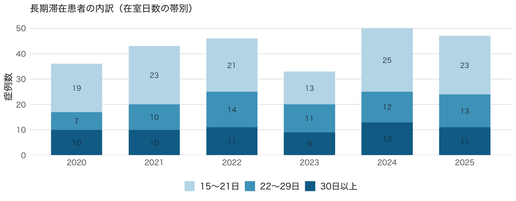

解説15日以上の長期滞在は今年度47例で、前年度の50例から減った。 入室数は増えているので、**入室に占める長期滞在の割合は9.0%→8.0%へ下がっている**。

ただし人数の増減そのものより、右の列を見てほしい。 **毎年、この数%の患者が延べ在室日数の3〜4割を使っている**（32〜44%）。 長期滞在の人数が年によって上下しても、**ベッドの大部分を少数の長期例が占めるという形は6年間変わっていない**。

### 診療科別の長期滞在

図 51診療科別の長期滞在

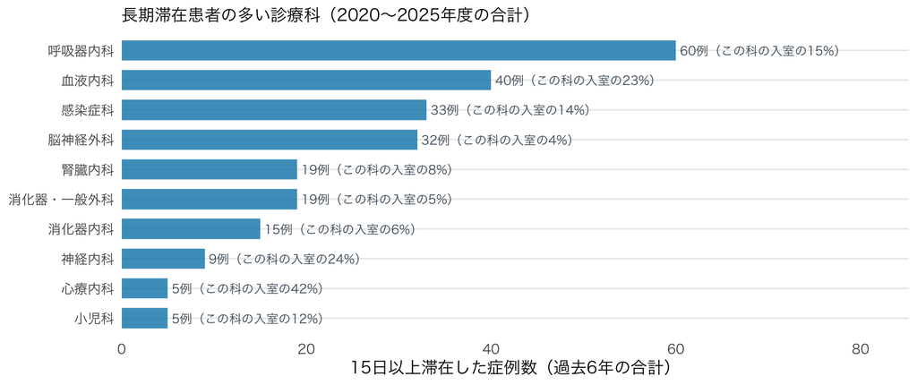

表 34診療科別の長期滞在

| 診療科 | 6年間の入室数 | うち15日以上 | 長期滞在率 | 今年度の15日以上 |
| --- | --- | --- | --- | --- |
| 呼吸器内科 | 393 | 60 | 15.3% | 11 |
| 血液内科 | 176 | 40 | 22.7% | 8 |
| 感染症科 | 240 | 33 | 13.8% | 5 |
| 脳神経外科 | 851 | 32 | 3.8% | 4 |
| 消化器・一般外科 | 420 | 19 | 4.5% | 2 |
| 腎臓内科 | 224 | 19 | 8.5% | 6 |
| 消化器内科 | 238 | 15 | 6.3% | 4 |
| 神経内科 | 38 | 9 | 23.7% | 0 |
| 小児科 | 43 | 5 | 11.6% | 3 |
| 心療内科 | 12 | 5 | 41.7% | 1 |

図 52診療科別の長期滞在

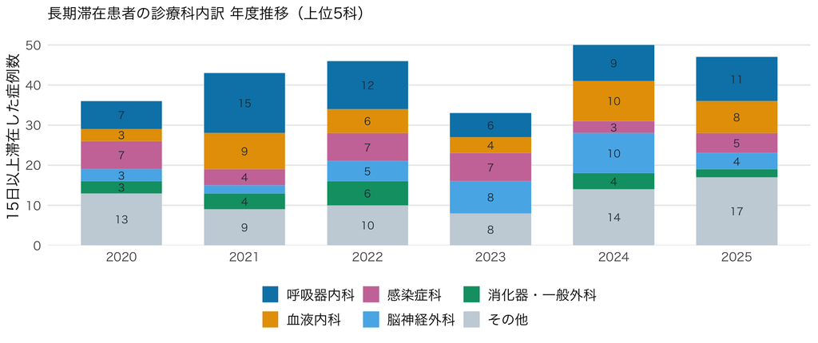

表 35診療科別の長期滞在

| 診療科 | 2020 | 2021 | 2022 | 2023 | 2024 | 2025 | 合計 |
| --- | --- | --- | --- | --- | --- | --- | --- |
| 呼吸器内科 | 7 | 15 | 12 | 6 | 9 | 11 | 60 |
| 血液内科 | 3 | 9 | 6 | 4 | 10 | 8 | 40 |
| 感染症科 | 7 | 4 | 7 | 7 | 3 | 5 | 33 |
| 脳神経外科 | 3 | 2 | 5 | 8 | 10 | 4 | 32 |
| 消化器・一般外科 | 3 | 4 | 6 | 0 | 4 | 2 | 19 |
| 腎臓内科 | 2 | 3 | 3 | 2 | 3 | 6 | 19 |
| 消化器内科 | 2 | 1 | 3 | 1 | 4 | 4 | 15 |
| 神経内科 | 2 | 2 | 2 | 3 | 0 | 0 | 9 |
| 小児科 | 0 | 1 | 0 | 0 | 1 | 3 | 5 |
| 心療内科 | 1 | 1 | 1 | 1 | 0 | 1 | 5 |

解説この図表は**2つの違うこと**を並べている。混同しないように分けて読んでほしい。

- **棒の長さ（＝症例数）** … その科の長期滞在患者を「何人抱えているか」。病床への負荷の総量
- **長期滞在率** … その科の患者が「長期化しやすいか」。1症例あたりのリスク

最も多いのは呼吸器内科で6年間に60例、次いで血液内科が40例。 **この2科だけで長期滞在例の39%を占める**。

ここで2つの列を並べると、性格の違う2つのパターンが見える。

- **血液内科型** — 入室176例に対し長期滞在率22.7%。**入室した患者の4〜5人に1人が2週間を超える**。数は多くないが、1例入るとベッドが長く塞がる
- **脳神経外科型** — 入室851例と最多だが長期滞在率は3.8%。**1例あたりは長引かないが、母数が大きいので実数は積み上がる**

**病床運用を考えるときは実数、目の前の患者の見通しを立てるときは率を見る**——同じ表から違う意思決定が出る。

読むときの注意が2つある。診療科は**入室時点**のもので、ICU滞在中に主科が移った症例も入室時の科で数えている。 また6年合計でも入室が2桁前半の科があり、**分母の小さい科の長期滞在率は数例の違いで大きく動く**ので、 率だけを見て「あの科は長引く」と判断しないこと。

## 15.6時間外入室と転帰

夜間・週末の入室は、日勤帯と同じ質の診療を受けられているか。 **平日日勤帯（月〜金の8〜17時）**とそれ以外（**時間外**＝夜間・週末）に分けて比べる。

表 36時間外入室と転帰

| 入室時間帯 | 症例数 | 緊急入室 | APACHE III（中央値） | ICU死亡 | 院内死亡 | SMR（95%CI） |
| --- | --- | --- | --- | --- | --- | --- |
| 平日日勤帯 | 296 | 49.0% | 53 | 4.1% | 14.7% | 0.66（0.48–0.89） |
| 時間外（夜間・週末） | 291 | 71.8% | 67 | 3.1% | 18.6% | 0.64（0.48–0.83） |

解説時間外入室は当然ながら緊急が多く重症度も高いため、**死亡率をそのまま比べてはいけない**。 比べるべきは重症度で補正したSMRである。 **両群のSMRの95%信頼区間が重なっていれば、「時間外に入室すると診療の質が落ちる」という証拠はない**と読む。 夜間・週末も同水準の成績を保てているかは夜勤体制の妥当性を測る国際的な論点（off-hours effect）であり、 この表は毎年同じ形で追う価値がある。

## 15.7臓器補助の重なり

重症度スコアとは別の、現場の実感に近い「治療の重さ」の物差しとして、 **人工呼吸・昇圧薬・腎代替療法・ECMO**のうちいくつを要したかで患者を分ける。

図 53臓器補助の重なり

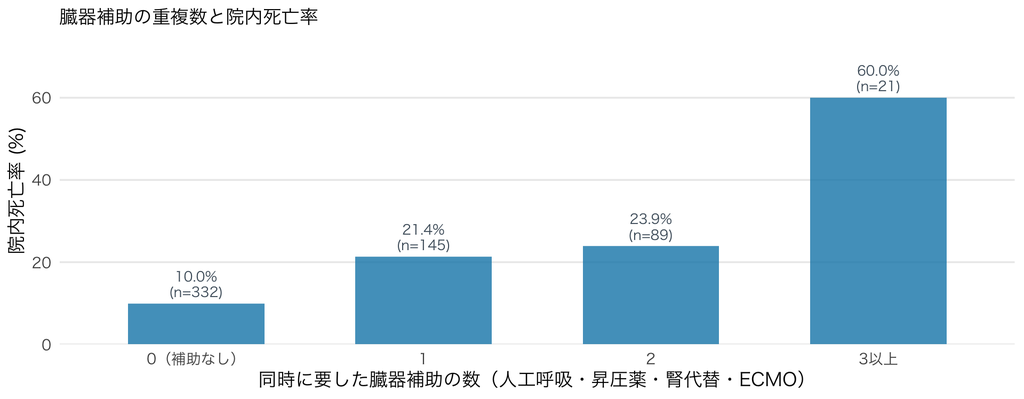

表 37臓器補助の重なり

| 臓器補助の数 | 症例数 | ICU死亡 | 院内死亡 | 在室日数（中央値） |
| --- | --- | --- | --- | --- |
| 0（補助なし） | 332 | 1.2% | 10.0% | 2 日 |
| 1 | 145 | 4.8% | 21.4% | 3 日 |
| 2 | 89 | 6.7% | 23.9% | 7 日 |
| 3以上 | 21 | 19.0% | 60.0% | 15 日 |

解説補助が1つ増えるごとに死亡率が階段状に上がる。 APACHEのような点数と違い、**「昇圧薬と人工呼吸が両方入っている患者」という現場の言葉のまま重症度を語れる**のがこの分け方の利点で、 看護配置や受け入れ判断の議論に直接使える。 なお補助数の多い群は例数が少ないため、単年の死亡率の上下は幅を持って読むこと。

# 16入室人数

## 16.1月別統計

図 54月別統計

[interactive chart not shown]

解説最多は01月の60例、最少は06月の40例。 月による差は最大20例あり、人員配置を月単位で見直す余地がある。

## 16.2日付別統計

図 55日付別統計

[interactive chart not shown]

解説1日の入室は0〜5例に収まっている。 年間587例を365日で割ると1日平均1.6例で、**日々の変動は平均の2〜3倍に達する**。 平均値ではなくピークを前提にした受け入れ体制が要る。

## 16.3疾患別(主病名で分類)

図 56疾患別(主病名で分類)

[interactive chart not shown]

## 16.4診療科

図 57診療科

[interactive chart not shown]

解説脳神経外科が144例で突出し、 以下、消化器・一般外科、呼吸器内科と続く。**外科系1科＋内科系複数科**という構成である。

## 16.5TOP5診療科の占有率

図 58TOP5診療科の占有率

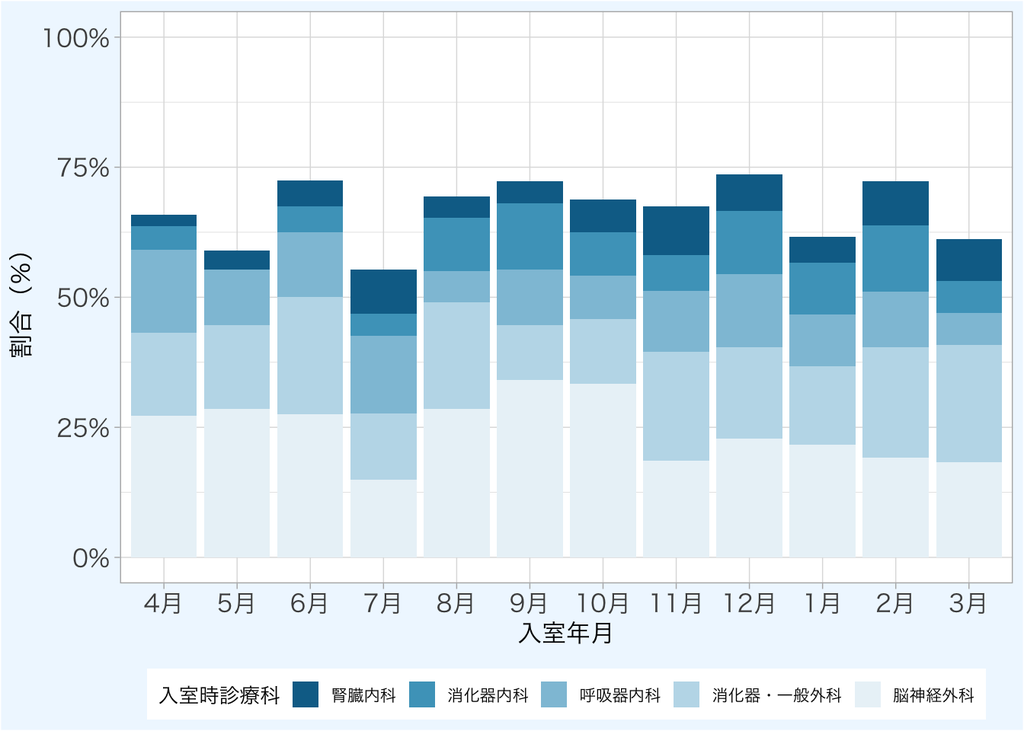

# 17曜日統計

- 入室は火曜が最多（112例）、日曜が最少（42例）
- 予定術後の入室は平日に集中し土日はほぼゼロ。手術枠がそのままICUの負荷カレンダーになる
- **土日の退室が少なく、金曜に退室できないと月曜まで在室が延びる**

## 17.1入室（全症例）

図 59入室（全症例）

[interactive chart not shown]

解説入室が最も多いのは火曜（112例）、 最も少ないのは日曜（42例）。 平日と休日の差がそのまま**平日日中の業務量の山**になっている。

## 17.2入室 (予定術後のみ)

図 60入室 (予定術後のみ)

[interactive chart not shown]

解説予定術後の入室は平日に集中し、土日はほぼゼロ。手術枠の設定がそのままICUの負荷カレンダーになっている。 週の後半に予定手術が偏ると、週末に長期滞在患者が積み残る構造につながる。

## 17.3退室

図 61退室

[interactive chart not shown]

解説退室が最も多いのは木曜。 土日の退室が少ないため、**金曜に退室できなかった患者は月曜まで在室が延びやすい**。 ここは在室日数を縮める余地が残っている部分である。

# 18入退室時間

## 18.1入室時間（全症例）

図 62入室時間（全症例）

[interactive chart not shown]

解説入室は14時前後にピークがあり、 これは予定手術の終了時間帯と重なる。深夜帯の入室は少ないが、緊急入室のため予測が立てにくい。

## 18.2退室時間（死亡除く）

図 63退室時間（死亡除く）

[interactive chart not shown]

解説退室は10時にピークがある。 17時以降または8時前の退室は0.5%（3例）にとどまり、 **準夜・夜勤帯の退室はよく抑えられている**。時間外の退室は転棟先の受け入れ体制が手薄になるため、この水準は維持したい。

## 18.3挿管時間（全症例）

図 64挿管時間（全症例）

[interactive chart not shown]

解説ICU入室後に挿管された症例の時刻分布。**特定の時刻への集中はなく**、日勤帯（8〜17時）に約53%が分布する一方、 **夜間・深夜の挿管も約47%ある**。 挿管のタイミングは患者の状態悪化で決まるため、抜管（次図）のように時刻を選べない。 **夜間帯にも気道緊急に対応できる体制が常に必要**というのが、この図の実務的な意味である。

## 18.4抜管時間（死亡除く 事故抜管含む）

図 65抜管時間（死亡除く 事故抜管含む）

[interactive chart not shown]

解説挿管と対照的に、**抜管は午前10〜11時にはっきり集中**し、約88%が日勤帯に行われている。 抜管は時刻を選べる処置であり、 **人手と応援が確保しやすい時間に気道の処置が集まっており、安全管理の面では望ましい形**。 一方でこの時間帯は退室（午前10〜11時のピーク）とも重なるため、**午前の数時間に業務が三重に積み上がっている**点は人員配置の検討材料になる。

## 18.5曜日×時刻でみる入退室

これまで別々に見てきた「曜日別」と「時刻別」を1枚に重ね、負荷が集中する交差点を探す。

図 66曜日×時刻でみる入退室

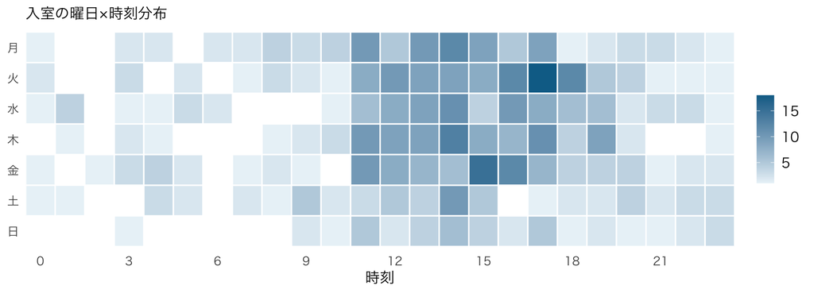

図 67曜日×時刻でみる入退室

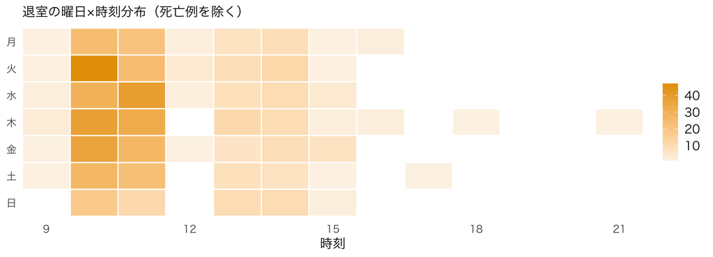